# 1. Business understanding and problem framing

What is the context of this problem and why are they trying to solve it?

Meet our client **PowerCo** - a major gas and electricity utility who is concerned about losing customers.

**Objective:**

- Low level of differentiation between products available.
- Customer service.
- Keeping customers for the long term.
- Building brand loyalty.

Key notes:

- Our client is PowerCo - a major gas and electricity utility that supplies to small and medium sized enterprises.
- The energy market has had a lot of change in recent years and there are more options than ever for customers to choose from.
- PowerCo are concerned about their customers leaving for better offers from other energy providers. When a customer leaves to use another service provider, this is called **churn**.
- This is becoming a big issue for PowerCo and they have engaged us **diagnose the reason why their customers are churning**.

Therefore, the assumption that one of the reasons is how "sensitive" the price is.

Problem: **How much is price a factor in a customer's choice to stay with or leave PowerCo?**

Price sensitivity is the degree to which demand changes when the cost of a product or service changes. Price sensitivity is commonly measured using the price elasticity of demand, which states that some consumers won't pay more if a lower-priced option is available.

In order to test the hypothesis of whether churn is driven by the customers'price sensitivity, we would need to model churn probabilities of customers, and derive the effect of prices on churn rates.

We would need the following data to be able to build the models.

1. Customer data - which should include characteristics of each client. For example, industry, historical electricity consumption, date joined as customer.
2. Churn data - which should indicate if customer has churned.
3. Historical price data - which should indicate the prices the client charges to each customer for both electricity and gas at granular time intervals.

client_data.csv:

- id: client company identifier.
- activity_new: category of the company's activity.
- channel_sales: code of the sales channel.
- cons_12m: electricity consumption of the past 12 months.
- cons_gas_12m: gas consumption of the past 12 months.
- cons_last_month: electricity consumption of the last month.
- date_activ: date of activation of the contract.
- date_end: registered date of the end of the contract.
- date_modif_prod: date of the last modification of the product.
- date_renewal: date of the next contract renewal.
- forecast_cons_12m: forecasted electricity consumption for next 12 months.
- forecast_cons_year: forecasted eclectricity consumption for the next calendar year.
- forecast_discount_energy: forecasted value of current discount.
- forecast_meter_rent_12m: forecasted bill of meter rental for the next 12 months.
- forecast_price_energy_off_peak: forecasted energy price for 1st period (off peak).
- forecast_price_energy_peak: forecasted energy price for 2nd period (peak).
- forecast_price_pow_off_peak: forecasted power price for 1st period (off peak).
- has_gas: indicated if client is also a gas client.
- imp_cons: current paid consumption.
- margin_gross_pow_ele: gross margin on power subscription.
- margin_net_pow_ele: net margin on power subscription.
- nb_prod_act: number of active products and services.
- net_margin: total net margin.
- num_years_antig = antiquity of the client (in number of years).
- origin_up: code of the electricity campaign the customer first subscribed to.
- pow_max: subscribed power.
- churn: has the client churned over the next 3 months.

price_data.csv:

- id: client company identifier.
- price_date: reference date.
- price_off_peak_var: price of energy for the 1st period (off peak).
- price_peak_var: price of energy for the 2nd period (peak).
- price_mid_peak_var: price of energy for the 3rd period (mid peak).
- price_off_peak_fix: price of power for the 1st period (off peak).
- price_peak_fix: price of power for the 2nd period (peak).
- price_mid_peak_fix: price of power for the 3rd period (mid peak).

# 2. Exploratory Data Analysis (EDA) and data cleaning

What data are we working with, what does it look like and how can we make it better?

2.1 Import packages

2.2 Loading data with Pandas

2.3 Descriptive statistics of data

2.4 Data visualization

## 2.1 Import packages

```python
import numpy as np
import pandas as pd
import seaborn as sns
import matplotlib.pyplot as plt
from datetime import datetime
from sklearn import metrics
from sklearn.model_selection import train_test_split
from sklearn.ensemble import RandomForestClassifier
from sklearn.metrics import confusion_matrix, classification_report
import warnings
warnings.filterwarnings("ignore", category = FutureWarning)

# Shows plots in jupyter notebook
%matplotlib inline

# Set plot style
sns.set(color_codes = True)
```

## 2.2 Loading data with Pandas

```python
client = pd.read_csv("client_data (1).csv")
price = pd.read_csv("price_data (1).csv")
```

```python
client.head(3)
```

|  | id | channel_sales | cons_12m | cons_gas_12m | cons_last_month | date_activ | date_end | date_modif_prod | date_renewal | forecast_cons_12m | ... | has_gas | imp_cons | margin_gross_pow_ele | margin_net_pow_ele | nb_prod_act | net_margin | num_years_antig | origin_up | pow_max | churn |
| --- | --- | --- | --- | --- | --- | --- | --- | --- | --- | --- | --- | --- | --- | --- | --- | --- | --- | --- | --- | --- | --- |
| 0 | 24011ae4ebbe3035111d65fa7c15bc57 | foosdfpfkusacimwkcsosbicdxkicaua | 0 | 54946 | 0 | 2013-06-15 | 2016-06-15 | 2015-11-01 | 2015-06-23 | 0.00 | ... | t | 0.0 | 25.44 | 25.44 | 2 | 678.99 | 3 | lxidpiddsbxsbosboudacockeimpuepw | 43.648 | 1 |
| 1 | d29c2c54acc38ff3c0614d0a653813dd | MISSING | 4660 | 0 | 0 | 2009-08-21 | 2016-08-30 | 2009-08-21 | 2015-08-31 | 189.95 | ... | f | 0.0 | 16.38 | 16.38 | 1 | 18.89 | 6 | kamkkxfxxuwbdslkwifmmcsiusiuosws | 13.800 | 0 |
| 2 | 764c75f661154dac3a6c254cd082ea7d | foosdfpfkusacimwkcsosbicdxkicaua | 544 | 0 | 0 | 2010-04-16 | 2016-04-16 | 2010-04-16 | 2015-04-17 | 47.96 | ... | f | 0.0 | 28.60 | 28.60 | 1 | 6.60 | 6 | kamkkxfxxuwbdslkwifmmcsiusiuosws | 13.856 | 0 |

3 rows × 26 columns

With the client data, we have a mix of numeric and categorical data, which we will need to transform before modelling later

```python
price.head(3)
```

|  | id | price_date | price_off_peak_var | price_peak_var | price_mid_peak_var | price_off_peak_fix | price_peak_fix | price_mid_peak_fix |
| --- | --- | --- | --- | --- | --- | --- | --- | --- |
| 0 | 038af19179925da21a25619c5a24b745 | 2015-01-01 | 0.151367 | 0.0 | 0.0 | 44.266931 | 0.0 | 0.0 |
| 1 | 038af19179925da21a25619c5a24b745 | 2015-02-01 | 0.151367 | 0.0 | 0.0 | 44.266931 | 0.0 | 0.0 |
| 2 | 038af19179925da21a25619c5a24b745 | 2015-03-01 | 0.151367 | 0.0 | 0.0 | 44.266931 | 0.0 | 0.0 |

With the price data, it is purely numeric data but we can see a lot of zeros

## 2.3 Descriptive statistics of data

**Data types:** It is useful to first understand the data that we are dealing with along with the data types of each column. The data types may dictate how we transform and engineer features.

```python
client.info()
```

```
<class 'pandas.core.frame.DataFrame'>
RangeIndex: 14606 entries, 0 to 14605
Data columns (total 26 columns):
 #   Column                          Non-Null Count  Dtype
---  ------                          --------------  -----
 0   id                              14606 non-null  object
 1   channel_sales                   14606 non-null  object
 2   cons_12m                        14606 non-null  int64
 3   cons_gas_12m                    14606 non-null  int64
 4   cons_last_month                 14606 non-null  int64
 5   date_activ                      14606 non-null  object
 6   date_end                        14606 non-null  object
 7   date_modif_prod                 14606 non-null  object
 8   date_renewal                    14606 non-null  object
 9   forecast_cons_12m               14606 non-null  float64
```

[output cut: 18 more lines]

```python
price.info()
```

```
<class 'pandas.core.frame.DataFrame'>
RangeIndex: 193002 entries, 0 to 193001
Data columns (total 8 columns):
 #   Column              Non-Null Count   Dtype
---  ------              --------------   -----
 0   id                  193002 non-null  object
 1   price_date          193002 non-null  object
 2   price_off_peak_var  193002 non-null  float64
 3   price_peak_var      193002 non-null  float64
 4   price_mid_peak_var  193002 non-null  float64
 5   price_off_peak_fix  193002 non-null  float64
 6   price_peak_fix      193002 non-null  float64
 7   price_mid_peak_fix  193002 non-null  float64
dtypes: float64(6), object(2)
memory usage: 11.8+ MB
```

**Statistics:** Now let's look at some statistics about the datasets

```python
client.describe()
```

|  | cons_12m | cons_gas_12m | cons_last_month | forecast_cons_12m | forecast_cons_year | forecast_discount_energy | forecast_meter_rent_12m | forecast_price_energy_off_peak | forecast_price_energy_peak | forecast_price_pow_off_peak | imp_cons | margin_gross_pow_ele | margin_net_pow_ele | nb_prod_act | net_margin | num_years_antig | pow_max | churn |
| --- | --- | --- | --- | --- | --- | --- | --- | --- | --- | --- | --- | --- | --- | --- | --- | --- | --- | --- |
| count | 1.460600e+04 | 1.460600e+04 | 14606.000000 | 14606.000000 | 14606.000000 | 14606.000000 | 14606.000000 | 14606.000000 | 14606.000000 | 14606.000000 | 14606.000000 | 14606.000000 | 14606.000000 | 14606.000000 | 14606.000000 | 14606.000000 | 14606.000000 | 14606.000000 |
| mean | 1.592203e+05 | 2.809238e+04 | 16090.269752 | 1868.614880 | 1399.762906 | 0.966726 | 63.086871 | 0.137283 | 0.050491 | 43.130056 | 152.786896 | 24.565121 | 24.562517 | 1.292346 | 189.264522 | 4.997809 | 18.135136 | 0.097152 |
| std | 5.734653e+05 | 1.629731e+05 | 64364.196422 | 2387.571531 | 3247.786255 | 5.108289 | 66.165783 | 0.024623 | 0.049037 | 4.485988 | 341.369366 | 20.231172 | 20.230280 | 0.709774 | 311.798130 | 1.611749 | 13.534743 | 0.296175 |
| min | 0.000000e+00 | 0.000000e+00 | 0.000000 | 0.000000 | 0.000000 | 0.000000 | 0.000000 | 0.000000 | 0.000000 | 0.000000 | 0.000000 | 0.000000 | 0.000000 | 1.000000 | 0.000000 | 1.000000 | 3.300000 | 0.000000 |
| 25% | 5.674750e+03 | 0.000000e+00 | 0.000000 | 494.995000 | 0.000000 | 0.000000 | 16.180000 | 0.116340 | 0.000000 | 40.606701 | 0.000000 | 14.280000 | 14.280000 | 1.000000 | 50.712500 | 4.000000 | 12.500000 | 0.000000 |
| 50% | 1.411550e+04 | 0.000000e+00 | 792.500000 | 1112.875000 | 314.000000 | 0.000000 | 18.795000 | 0.143166 | 0.084138 | 44.311378 | 37.395000 | 21.640000 | 21.640000 | 1.000000 | 112.530000 | 5.000000 | 13.856000 | 0.000000 |
| 75% | 4.076375e+04 | 0.000000e+00 | 3383.000000 | 2401.790000 | 1745.750000 | 0.000000 | 131.030000 | 0.146348 | 0.098837 | 44.311378 | 193.980000 | 29.880000 | 29.880000 | 1.000000 | 243.097500 | 6.000000 | 19.172500 | 0.000000 |
| max | 6.207104e+06 | 4.154590e+06 | 771203.000000 | 82902.830000 | 175375.000000 | 30.000000 | 599.310000 | 0.273963 | 0.195975 | 59.266378 | 15042.790000 | 374.640000 | 374.640000 | 32.000000 | 24570.650000 | 13.000000 | 320.000000 | 1.000000 |

The describe method gives us a lot of information about the client data. The key point to take away from this is that we have highly skewed data, as exhibited by the percentile values.

```python
price.describe()
```

|  | price_off_peak_var | price_peak_var | price_mid_peak_var | price_off_peak_fix | price_peak_fix | price_mid_peak_fix |
| --- | --- | --- | --- | --- | --- | --- |
| count | 193002.000000 | 193002.000000 | 193002.000000 | 193002.000000 | 193002.000000 | 193002.000000 |
| mean | 0.141027 | 0.054630 | 0.030496 | 43.334477 | 10.622875 | 6.409984 |
| std | 0.025032 | 0.049924 | 0.036298 | 5.410297 | 12.841895 | 7.773592 |
| min | 0.000000 | 0.000000 | 0.000000 | 0.000000 | 0.000000 | 0.000000 |
| 25% | 0.125976 | 0.000000 | 0.000000 | 40.728885 | 0.000000 | 0.000000 |
| 50% | 0.146033 | 0.085483 | 0.000000 | 44.266930 | 0.000000 | 0.000000 |
| 75% | 0.151635 | 0.101673 | 0.072558 | 44.444710 | 24.339581 | 16.226389 |
| max | 0.280700 | 0.229788 | 0.114102 | 59.444710 | 36.490692 | 17.458221 |

Overall the price data looks goods

## 2.4 Data visualization

Now let's drive a bit deeper into the dataframes

```python
# Plot stacked bars with annotations
def plot_stacked_bars(dataframe, title_, size_ = (18,10), rot_ = 0, legend_ = "lower right"):
    ax = dataframe.plot(kind = "bar", stacked = True, figsize = size_, rot = rot_, title = title_)
    #  Annotate bars
    annotate_stacked_bars(ax, textsize = 14)
    # Rename legend
    plt.legend(["Retention", "Churn"], loc = legend_)
    # Labels
    plt.ylabel("Company base (%)")
    plt.show()

# Add value annotations to the bars
def annotate_stacked_bars(ax, pad = 0.99, colour = "white", textsize = 13):
    # Iterate over the plotted rectanges/ bars
    for p in ax.patches:
        # Calculate annotation
        value = str(round(p.get_height(),1))
        # If value is 0 do not annotate
        if value == '0.0':
            continue
        ax.annotate(value, ((p.get_x() + p.get_width()/2)*pad - 0.05, (p.get_y() + p.get_height()/2)*pad), color = colour, size = textsize)
```

### a Churn

```python
churn = client[['id','churn']]
churn.columns = ['Companies','churn']
churn_total = churn.groupby(churn['churn']).count()
churn_percentage = (churn_total / churn_total.sum())*100
churn_percentage
```

| churn | Companies |
| --- | --- |
| 0 | 90.284814 |
| 1 | 9.715186 |

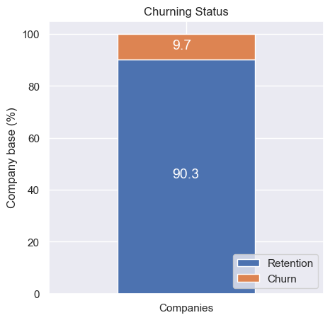

```python
plot_stacked_bars(churn_percentage.transpose(), title_ = "Churning Status", size_ = (5,5), rot_ = 0, legend_ = "lower right")
```

This visualization shows how many companies churned and how many companies did not churn. We can see from this that the churn rate is approximately 10%. This is actually a very good churn rate, the closer the rate is to 0% the better.

The next series of visualizations were created in an attempt to try and dive deeper into how churn changes based on other factors. This is useful for us to investigate because it may help us to understand factors that drive churn.

### b. Sales Channel

```python
channel = client[['id','channel_sales', 'churn']]
channel.columns = ['id','Channel Sales', 'churn']

channel_total = channel.groupby([channel['Channel Sales'], channel['churn']])['id'].count().unstack(level = 1).fillna(0)
channel_churn = (channel_total.div(channel_total.sum(axis = 1), axis = 0)*100).sort_values(by = [1], ascending = False)
channel_churn
```

| churn Channel Sales | 0 | 1 |
| --- | --- | --- |
| foosdfpfkusacimwkcsosbicdxkicaua | 87.859046 | 12.140954 |
| usilxuppasemubllopkaafesmlibmsdf | 89.963636 | 10.036364 |
| ewpakwlliwisiwduibdlfmalxowmwpci | 91.601344 | 8.398656 |
| MISSING | 92.402685 | 7.597315 |
| lmkebamcaaclubfxadlmueccxoimlema | 94.411286 | 5.588714 |
| epumfxlbckeskwekxbiuasklxalciiuu | 100.000000 | 0.000000 |
| fixdbufsefwooaasfcxdxadsiekoceaa | 100.000000 | 0.000000 |
| sddiedcslfslkckwlfkdpoeeailfpeds | 100.000000 | 0.000000 |

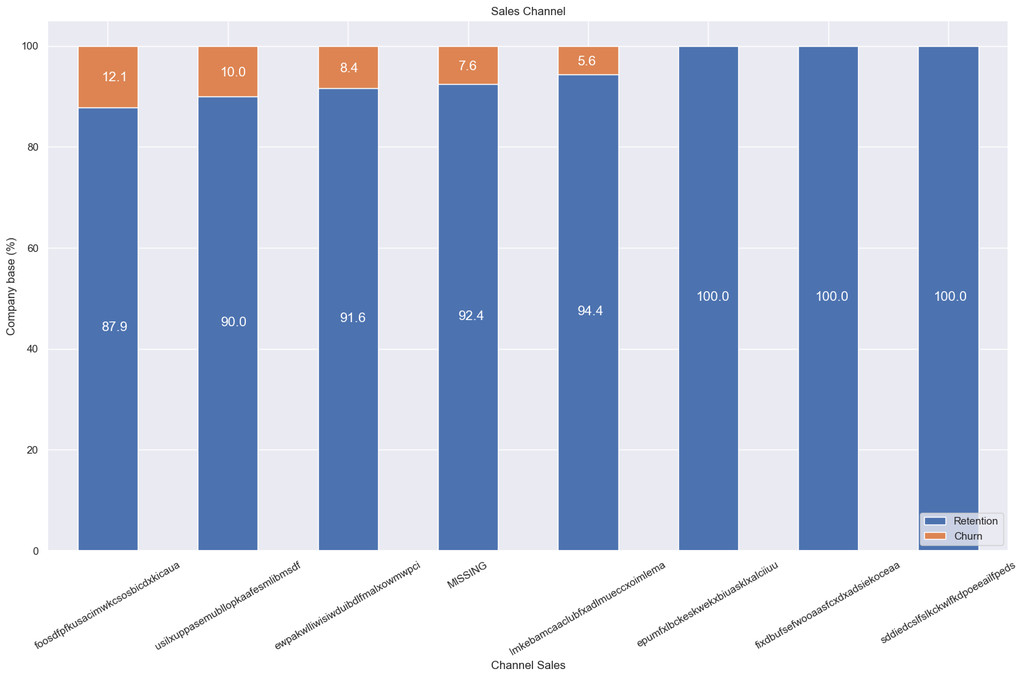

```python
plot_stacked_bars(channel_churn, title_ = "Sales Channel", size_ = (18,10), rot_ = 30, legend_ = "lower right")
```

We see that for sales channel, there are some sales channels that yield customers churning but there are other sales channels that have no customers churning.

Interestingly, the churning customers are distributed over 5 different values for channel_sales. As well as this, the value of MISSING has a churn rate of 7.6%. MISSING indicates a missing value and was added by the team when they were cleaning the dataset. This feature could be an important feature when it comes to building our model.

### c. Consumption

Let's see the distribution of the consumption in the last year and month. Since the consumption data is univariate, let's use histograms to visualize their distribution

```python
consumption = client[['id', 'cons_12m', 'cons_gas_12m', 'cons_last_month', 'imp_cons', 'has_gas', 'churn']]
```

```python
# Plot variable distribution in a stacked histogram of churned or retained company
def plot_distribution(dataframe, column, ax, bins_ = 50):
    # Create a temporal dataframe with the data to be plot
    temp = pd.DataFrame({"Retention": dataframe[dataframe["churn"] == 0][column], "Churn": dataframe[dataframe["churn"] == 1][column]})
    # Plot the histogram
    temp[["Retention", "Churn"]].plot(kind = 'hist', bins = bins_, ax = ax, stacked = True)
    # X-axis label
    ax.set_xlabel(column)
    # Change the x-axis to plain style
    ax.ticklabel_format(style = 'plain', axis = 'x')
```

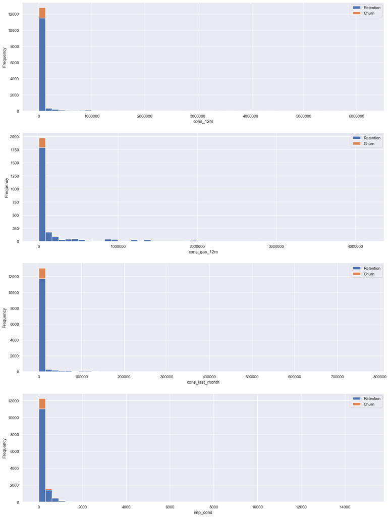

```python
fig, axs = plt.subplots(nrows = 4, figsize = (18,25))

plot_distribution(consumption, 'cons_12m', ax = axs[0], bins_ = 50)
plot_distribution(consumption[consumption['has_gas'] == 't'], 'cons_gas_12m', ax = axs[1], bins_ = 50)
plot_distribution(consumption, 'cons_last_month', ax = axs[2], bins_ = 50)
plot_distribution(consumption, 'imp_cons', ax = axs[3], bins_ = 50)
```

Clearly, the consumption data is highly positively skewed, presenting a very long right-tail towards the higher values of the distribution. The values on the higher and lower end of the distributionn are likely to be outliears. We can use a standard plot to visualise the outliers in more detail.

A boxplot is a standardized way of a displaying the distribution based on a five number summary:

- Minimum
- First quartile (Q1)
- Median
- Third quartile (Q3)
- Maximum

It can reveal outliers and what their values are. It can also tell us if our data is symmetrical, how tightly our data is grouped and if/how our data is skewed.

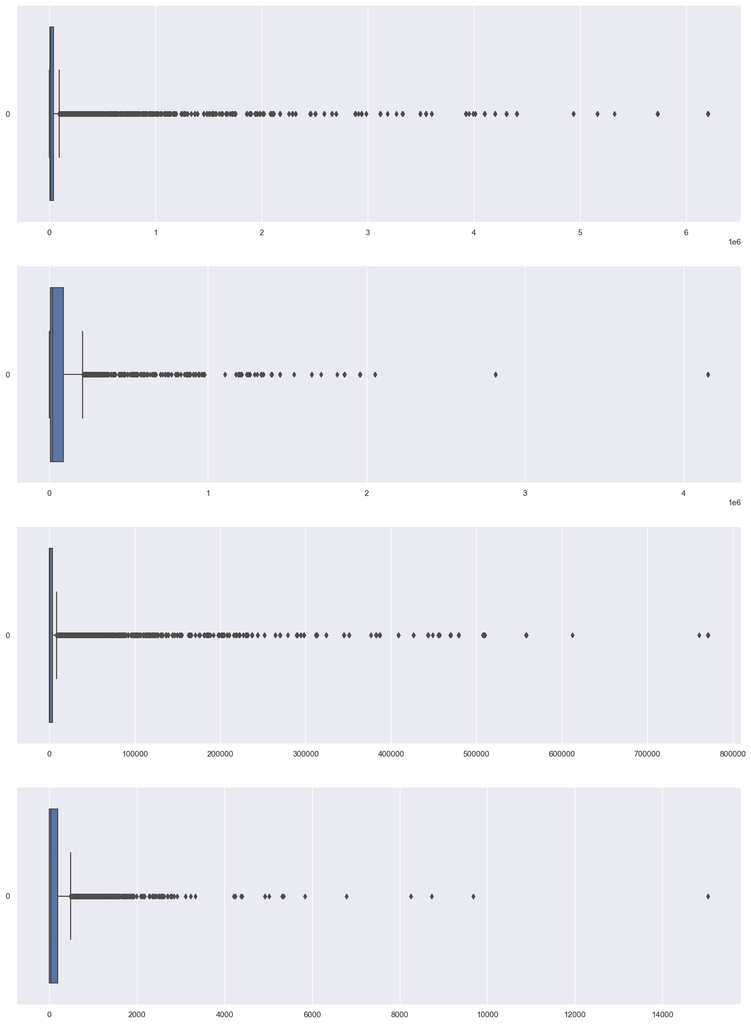

```python
fig, axs = plt.subplots(nrows = 4, figsize = (18,25))

# Plot histogram
sns.boxplot(consumption["cons_12m"], ax = axs[0], orient = 'h')
sns.boxplot(consumption[consumption['has_gas'] == 't']['cons_gas_12m'], ax = axs[1], orient = 'h')
sns.boxplot(consumption["cons_last_month"], ax = axs[2], orient = 'h')
sns.boxplot(consumption["imp_cons"], ax = axs[3], orient = 'h')
```

We notice that the distribution of consumption is very skewed, this is called a positive skew since it is biased towards lower values on the x axis.

This is interesting because you may decide to treat this column to reduce the skewness later on during feature engineering. But also because we may want to visualize if there are any outliers within this column.

To investigate outliers, we use a boxplot. From the boxplot we can see that with the column as it is there are definitely some outliers. Once again this is interesting because we may choose to remove some of these outliers later.

### d. Forecast

```python
forecast = client[["forecast_cons_12m", "forecast_cons_year", "forecast_discount_energy", "forecast_meter_rent_12m", "forecast_price_energy_off_peak", "forecast_price_energy_peak", "forecast_price_pow_off_peak", "churn"]]
forecast.head(3)
```

|  | forecast_cons_12m | forecast_cons_year | forecast_discount_energy | forecast_meter_rent_12m | forecast_price_energy_off_peak | forecast_price_energy_peak | forecast_price_pow_off_peak | churn |
| --- | --- | --- | --- | --- | --- | --- | --- | --- |
| 0 | 0.00 | 0 | 0.0 | 1.78 | 0.114481 | 0.098142 | 40.606701 | 1 |
| 1 | 189.95 | 0 | 0.0 | 16.27 | 0.145711 | 0.000000 | 44.311378 | 0 |
| 2 | 47.96 | 0 | 0.0 | 38.72 | 0.165794 | 0.087899 | 44.311378 | 0 |

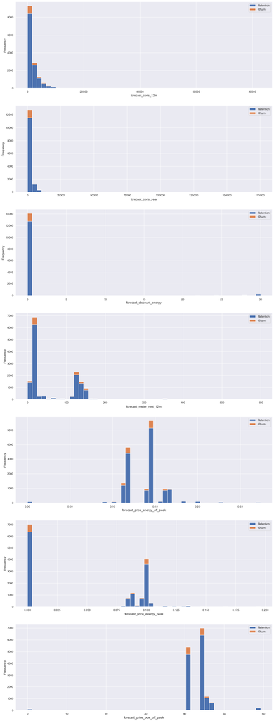

```python
fig, axs = plt.subplots(nrows = 7, figsize = (18,50))

# Plot histogram
plot_distribution(client, "forecast_cons_12m", axs[0])
plot_distribution(client, "forecast_cons_year", axs[1])
plot_distribution(client, "forecast_discount_energy", axs[2])
plot_distribution(client, "forecast_meter_rent_12m", axs[3])
plot_distribution(client, "forecast_price_energy_off_peak", axs[4])
plot_distribution(client, "forecast_price_energy_peak", axs[5])
plot_distribution(client, "forecast_price_pow_off_peak", axs[6])
```

Similarly to the consumption plots, we can observe that a lot of the variables are highly positively skewed, creating a very long tail for the higher values.

### e. Contract type

```python
contract_type = client[["id", "has_gas", "churn"]]
contract = contract_type.groupby([contract_type['churn'], contract_type['has_gas']])['id'].count().unstack(level = 0)
contract_percentage = (contract.div(contract.sum(axis = 1), axis = 0)*100).sort_values(by = [1], ascending = True)
contract_percentage
```

| churn has_gas | 0 | 1 |
| --- | --- | --- |
| t | 91.814410 | 8.185590 |
| f | 89.945629 | 10.054371 |

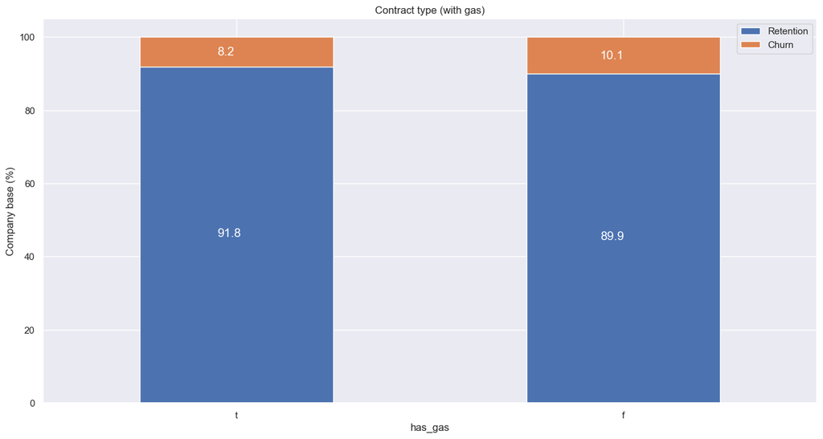

```python
plot_stacked_bars(contract_percentage, title_ = "Contract type (with gas)", size_ = (16,8), rot_ = 0, legend_="upper right")
```

For contract type, we see quite an even split for customers churning. This is interesting because this may suggest that contract type is not a driving factor towards churn rate.

### f. Margins

```python
margin = client[["id","margin_gross_pow_ele","margin_net_pow_ele", "net_margin"]]
```

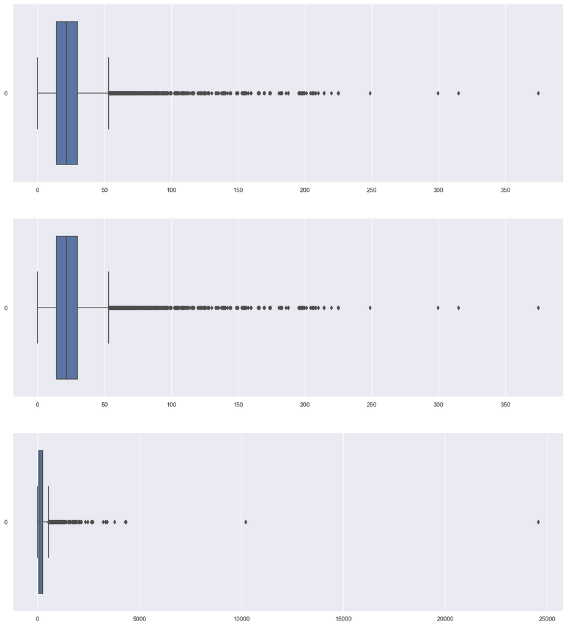

```python
fig, axs = plt.subplots(nrows = 3, figsize = (18,20))

# Plot histogram
sns.boxplot(margin["margin_gross_pow_ele"], ax = axs[0], orient = 'h')
sns.boxplot(margin["margin_net_pow_ele"], ax = axs[1], orient = 'h')
sns.boxplot(margin["net_margin"], ax = axs[2], orient = 'h')
```

### g. Subscribed power

```python
power = client[['id', 'pow_max', 'churn']]
power.head()
```

|  | id | pow_max | churn |
| --- | --- | --- | --- |
| 0 | 24011ae4ebbe3035111d65fa7c15bc57 | 43.648 | 1 |
| 1 | d29c2c54acc38ff3c0614d0a653813dd | 13.800 | 0 |
| 2 | 764c75f661154dac3a6c254cd082ea7d | 13.856 | 0 |
| 3 | bba03439a292a1e166f80264c16191cb | 13.200 | 0 |
| 4 | 149d57cf92fc41cf94415803a877cb4b | 19.800 | 0 |

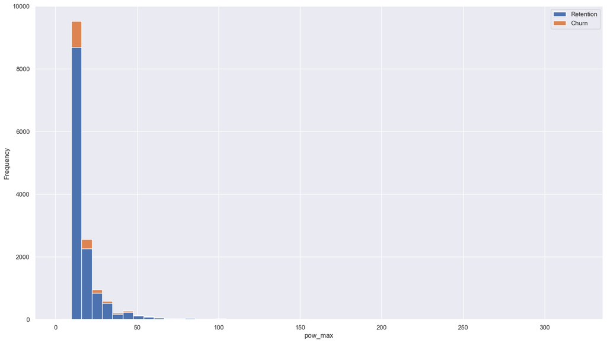

```python
fig, axs = plt.subplots(nrows = 1, figsize = (18, 10))
plot_distribution(power, 'pow_max', axs)
```

### h. Other columns

```python
others = client[['id', 'nb_prod_act', 'num_years_antig', 'origin_up', 'churn']]
products = others.groupby([others['nb_prod_act'], others['churn']])['id'].count().unstack(level = 1).fillna(0)
products_percentage = (products.div(products.sum(axis = 1), axis = 0)*100).sort_values(by = [1], ascending = False)
products_percentage
```

| churn nb_prod_act | 0 | 1 |
| --- | --- | --- |
| 4 | 90.000000 | 10.000000 |
| 1 | 90.018371 | 9.981629 |
| 3 | 90.057361 | 9.942639 |
| 5 | 90.322581 | 9.677419 |
| 2 | 91.492843 | 8.507157 |
| 6 | 100.000000 | 0.000000 |
| 8 | 100.000000 | 0.000000 |
| 9 | 100.000000 | 0.000000 |
| 10 | 100.000000 | 0.000000 |
| 32 | 100.000000 | 0.000000 |

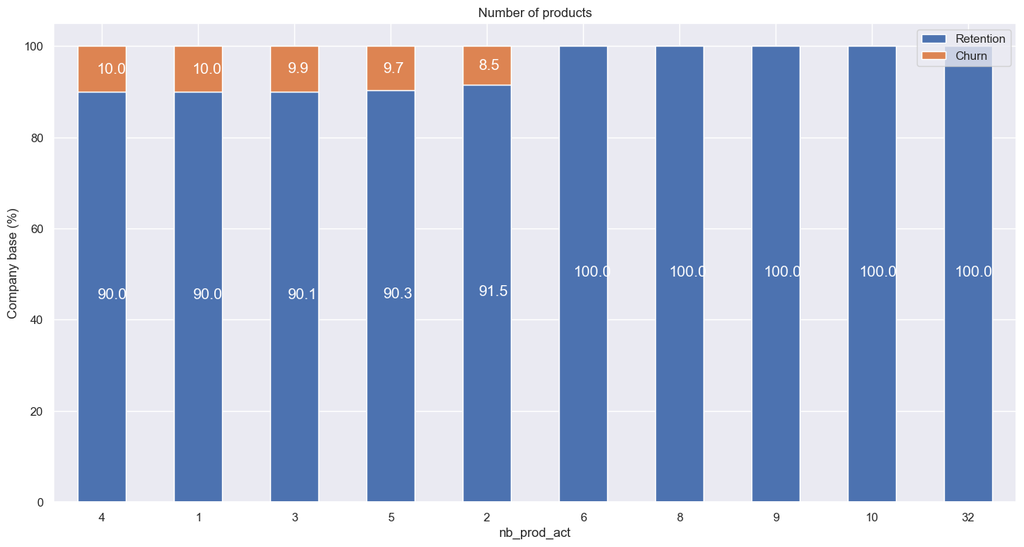

```python
plot_stacked_bars(products_percentage, title_ = "Number of products", size_=(16,8), rot_=0, legend_="upper right")
```

```python
years_antig = others.groupby([others['num_years_antig'], others['churn']])['id'].count().unstack(level = 1).fillna(0)
years_antig_percentage = (years_antig.div(years_antig.sum(axis = 1), axis = 0)*100)
years_antig_percentage
```

| churn num_years_antig | 0 | 1 |
| --- | --- | --- |
| 1 | 100.000000 | 0.000000 |
| 2 | 72.727273 | 27.272727 |
| 3 | 86.477600 | 13.522400 |
| 4 | 88.146660 | 11.853340 |
| 5 | 91.368148 | 8.631852 |
| 6 | 92.891592 | 7.108408 |
| 7 | 91.748527 | 8.251473 |
| 8 | 95.145631 | 4.854369 |
| 9 | 98.913043 | 1.086957 |
| 10 | 95.061728 | 4.938272 |
| 11 | 93.513514 | 6.486486 |
| 12 | 90.000000 | 10.000000 |
| 13 | 92.307692 | 7.692308 |

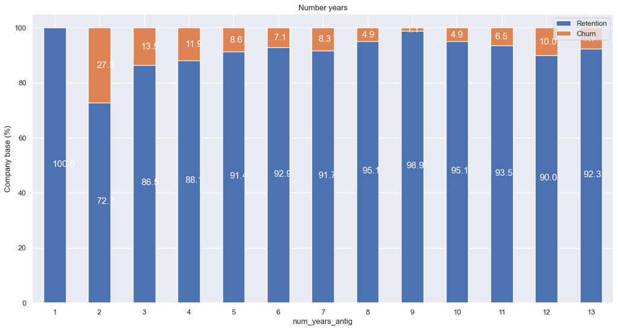

```python
plot_stacked_bars(years_antig_percentage, title_ = "Number years", size_=(16,8), rot_=0, legend_="upper right")
```

```python
origin = others.groupby([others["origin_up"], others["churn"]])["id"].count().unstack(level = 1).fillna(0)
origin_percentage = (origin.div(origin.sum(axis = 1), axis = 0)*100).sort_values(by = [1], ascending = False)
origin_percentage
```

| churn origin_up | 0 | 1 |
| --- | --- | --- |
| lxidpiddsbxsbosboudacockeimpuepw | 87.417219 | 12.582781 |
| ldkssxwpmemidmecebumciepifcamkci | 91.613723 | 8.386277 |
| MISSING | 93.750000 | 6.250000 |
| kamkkxfxxuwbdslkwifmmcsiusiuosws | 93.991616 | 6.008384 |
| ewxeelcelemmiwuafmddpobolfuxioce | 100.000000 | 0.000000 |
| usapbepcfoloekilkwsdiboslwaxobdp | 100.000000 | 0.000000 |

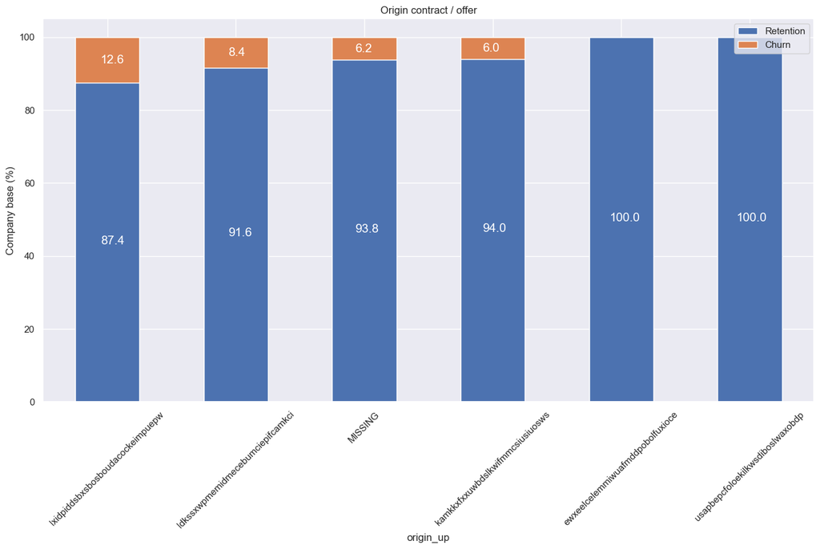

```python
plot_stacked_bars(origin_percentage, title_ = "Origin contract / offer", size_=(16,8), rot_=45, legend_="upper right")
```

# 3. Feature Engineering

Can we enrich this dataset using our own expertise or third party information?

Feature engineering refers to:

- Addition
- Deletion
- Combinatin
- Mutation

Our dataset can improve machine learning model training, leading to better performance and greater accuracy.

## 3.1 Difference between off-peak prices in December and preceding Junuary

Maybe the difference between off-peak prices in December and January the preceding year could be a significant feature when predicting churn.

```python
price["price_date"] = pd.to_datetime(price["price_date"], format = '%Y-%m-%d')
```

```python
price.info()
```

```
<class 'pandas.core.frame.DataFrame'>
RangeIndex: 193002 entries, 0 to 193001
Data columns (total 8 columns):
 #   Column              Non-Null Count   Dtype
---  ------              --------------   -----
 0   id                  193002 non-null  object
 1   price_date          193002 non-null  datetime64[ns]
 2   price_off_peak_var  193002 non-null  float64
 3   price_peak_var      193002 non-null  float64
 4   price_mid_peak_var  193002 non-null  float64
 5   price_off_peak_fix  193002 non-null  float64
 6   price_peak_fix      193002 non-null  float64
 7   price_mid_peak_fix  193002 non-null  float64
dtypes: datetime64[ns](1), float64(6), object(1)
memory usage: 11.8+ MB
```

```python
# Group off-peak by companies and month
monthly_price_by_id = price.groupby(['id', 'price_date']).agg({'price_off_peak_var': 'mean', 'price_off_peak_fix': 'mean'}).reset_index()
monthly_price_by_id
```

|  | id | price_date | price_off_peak_var | price_off_peak_fix |
| --- | --- | --- | --- | --- |
| 0 | 0002203ffbb812588b632b9e628cc38d | 2015-01-01 | 0.126098 | 40.565969 |
| 1 | 0002203ffbb812588b632b9e628cc38d | 2015-02-01 | 0.126098 | 40.565969 |
| 2 | 0002203ffbb812588b632b9e628cc38d | 2015-03-01 | 0.128067 | 40.728885 |
| 3 | 0002203ffbb812588b632b9e628cc38d | 2015-04-01 | 0.128067 | 40.728885 |
| 4 | 0002203ffbb812588b632b9e628cc38d | 2015-05-01 | 0.128067 | 40.728885 |
| ... | ... | ... | ... | ... |
| 192997 | ffff7fa066f1fb305ae285bb03bf325a | 2015-08-01 | 0.119916 | 40.728885 |
| 192998 | ffff7fa066f1fb305ae285bb03bf325a | 2015-09-01 | 0.119916 | 40.728885 |
| 192999 | ffff7fa066f1fb305ae285bb03bf325a | 2015-10-01 | 0.119916 | 40.728885 |
| 193000 | ffff7fa066f1fb305ae285bb03bf325a | 2015-11-01 | 0.119916 | 40.728885 |
| 193001 | ffff7fa066f1fb305ae285bb03bf325a | 2015-12-01 | 0.119916 | 40.728885 |

193002 rows × 4 columns

```python
# Get january and december prices
jan_prices = monthly_price_by_id.groupby('id').first().reset_index()
dec_prices = monthly_price_by_id.groupby('id').last().reset_index()
dec_prices.head()
```

|  | id | price_date | price_off_peak_var | price_off_peak_fix |
| --- | --- | --- | --- | --- |
| 0 | 0002203ffbb812588b632b9e628cc38d | 2015-12-01 | 0.119906 | 40.728885 |
| 1 | 0004351ebdd665e6ee664792efc4fd13 | 2015-12-01 | 0.143943 | 44.444710 |
| 2 | 0010bcc39e42b3c2131ed2ce55246e3c | 2015-12-01 | 0.201280 | 45.944710 |
| 3 | 0010ee3855fdea87602a5b7aba8e42de | 2015-12-01 | 0.113068 | 40.728885 |
| 4 | 00114d74e963e47177db89bc70108537 | 2015-12-01 | 0.145440 | 44.266930 |

```python
# Calculate the difference
diff = pd.merge(dec_prices.rename(columns = {'price_off_peak_var': 'dec_1', 'price_off_peak_fix': 'dec_2'}), jan_prices.drop(columns = 'price_date'), on = 'id')
diff['offpeak_dec_january_energy'] = diff['dec_1'] - diff['price_off_peak_var']
diff['offpeak_dec_january_power'] = diff['dec_2'] - diff['price_off_peak_fix']
diff = diff[['id', 'offpeak_dec_january_energy', 'offpeak_dec_january_power']]
diff
```

|  | id | offpeak_dec_january_energy | offpeak_dec_january_power |
| --- | --- | --- | --- |
| 0 | 0002203ffbb812588b632b9e628cc38d | -0.006192 | 0.162916 |
| 1 | 0004351ebdd665e6ee664792efc4fd13 | -0.004104 | 0.177779 |
| 2 | 0010bcc39e42b3c2131ed2ce55246e3c | 0.050443 | 1.500000 |
| 3 | 0010ee3855fdea87602a5b7aba8e42de | -0.010018 | 0.162916 |
| 4 | 00114d74e963e47177db89bc70108537 | -0.003994 | -0.000001 |
| ... | ... | ... | ... |
| 16091 | ffef185810e44254c3a4c6395e6b4d8a | -0.050232 | -0.335085 |
| 16092 | fffac626da707b1b5ab11e8431a4d0a2 | -0.003778 | 0.177779 |
| 16093 | fffc0cacd305dd51f316424bbb08d1bd | -0.001760 | 0.164916 |
| 16094 | fffe4f5646aa39c7f97f95ae2679ce64 | -0.009391 | 0.162916 |
| 16095 | ffff7fa066f1fb305ae285bb03bf325a | -0.009528 | 0.162916 |

16096 rows × 3 columns

```python
df = pd.merge(price, diff, on = 'id')
df.head()
```

|  | id | price_date | price_off_peak_var | price_peak_var | price_mid_peak_var | price_off_peak_fix | price_peak_fix | price_mid_peak_fix | offpeak_dec_january_energy | offpeak_dec_january_power |
| --- | --- | --- | --- | --- | --- | --- | --- | --- | --- | --- |
| 0 | 038af19179925da21a25619c5a24b745 | 2015-01-01 | 0.151367 | 0.0 | 0.0 | 44.266931 | 0.0 | 0.0 | -0.005508 | 0.177779 |
| 1 | 038af19179925da21a25619c5a24b745 | 2015-02-01 | 0.151367 | 0.0 | 0.0 | 44.266931 | 0.0 | 0.0 | -0.005508 | 0.177779 |
| 2 | 038af19179925da21a25619c5a24b745 | 2015-03-01 | 0.151367 | 0.0 | 0.0 | 44.266931 | 0.0 | 0.0 | -0.005508 | 0.177779 |
| 3 | 038af19179925da21a25619c5a24b745 | 2015-04-01 | 0.149626 | 0.0 | 0.0 | 44.266931 | 0.0 | 0.0 | -0.005508 | 0.177779 |
| 4 | 038af19179925da21a25619c5a24b745 | 2015-05-01 | 0.149626 | 0.0 | 0.0 | 44.266931 | 0.0 | 0.0 | -0.005508 | 0.177779 |

## 3.2 Average price changes across periods

We have the average price changes across periods. This is measure of the average price change by company between peak, mid-peak and off-peak periods.

```python
# Aggregate average prices per period by company
mean_prices = price.groupby(['id']).agg({'price_off_peak_var': 'mean', 'price_peak_var': 'mean', 'price_mid_peak_var': 'mean', 'price_mid_peak_var': 'mean', 'price_off_peak_fix': 'mean', 'price_peak_fix': 'mean', 'price_mid_peak_fix': 'mean'}).reset_index()
mean_prices
```

|  | id | price_off_peak_var | price_peak_var | price_mid_peak_var | price_off_peak_fix | price_peak_fix | price_mid_peak_fix |
| --- | --- | --- | --- | --- | --- | --- | --- |
| 0 | 0002203ffbb812588b632b9e628cc38d | 0.124338 | 0.103794 | 0.073160 | 40.701732 | 24.421038 | 16.280694 |
| 1 | 0004351ebdd665e6ee664792efc4fd13 | 0.146426 | 0.000000 | 0.000000 | 44.385450 | 0.000000 | 0.000000 |
| 2 | 0010bcc39e42b3c2131ed2ce55246e3c | 0.181558 | 0.000000 | 0.000000 | 45.319710 | 0.000000 | 0.000000 |
| 3 | 0010ee3855fdea87602a5b7aba8e42de | 0.118757 | 0.098292 | 0.069032 | 40.647427 | 24.388455 | 16.258971 |
| 4 | 00114d74e963e47177db89bc70108537 | 0.147926 | 0.000000 | 0.000000 | 44.266930 | 0.000000 | 0.000000 |
| ... | ... | ... | ... | ... | ... | ... | ... |
| 16091 | ffef185810e44254c3a4c6395e6b4d8a | 0.138863 | 0.115125 | 0.080780 | 40.896427 | 24.637456 | 16.507972 |
| 16092 | fffac626da707b1b5ab11e8431a4d0a2 | 0.147137 | 0.000000 | 0.000000 | 44.311375 | 0.000000 | 0.000000 |
| 16093 | fffc0cacd305dd51f316424bbb08d1bd | 0.153879 | 0.129497 | 0.094842 | 41.160171 | 24.895768 | 16.763569 |
| 16094 | fffe4f5646aa39c7f97f95ae2679ce64 | 0.123858 | 0.103499 | 0.073735 | 40.606699 | 24.364017 | 16.242678 |
| 16095 | ffff7fa066f1fb305ae285bb03bf325a | 0.125360 | 0.104895 | 0.075635 | 40.647427 | 24.388455 | 16.258971 |

16096 rows × 7 columns

```python
# Calculate the mean difference between consecutive periods

## Energy
mean_prices['off_peak_peak_var_mean_diff'] = mean_prices['price_off_peak_var'] - mean_prices['price_peak_var']
mean_prices['peak_mid_peak_var_mean_diff'] = mean_prices['price_peak_var'] - mean_prices['price_mid_peak_var']
mean_prices['off_peak_mid_peak_var_mean_diff'] = mean_prices['price_off_peak_var'] - mean_prices['price_mid_peak_var']

## Power
mean_prices['off_peak_peak_fix_mean_diff'] = mean_prices['price_off_peak_fix'] - mean_prices['price_peak_fix']
mean_prices['peak_mid_peak_fix_mean_diff'] = mean_prices['price_peak_fix'] - mean_prices['price_mid_peak_fix']
mean_prices['off_peak_mid_peak_fix_mean_diff'] = mean_prices['price_off_peak_fix'] - mean_prices['price_mid_peak_fix']
```

```python
columns = ['id', 'off_peak_peak_var_mean_diff', 'peak_mid_peak_var_mean_diff', 'off_peak_mid_peak_var_mean_diff', 'off_peak_peak_fix_mean_diff', 'peak_mid_peak_fix_mean_diff', 'off_peak_mid_peak_fix_mean_diff']

df = pd.merge(df, mean_prices[columns], on = 'id')
df.head()
```

|  | id | price_date | price_off_peak_var | price_peak_var | price_mid_peak_var | price_off_peak_fix | price_peak_fix | price_mid_peak_fix | offpeak_dec_january_energy | offpeak_dec_january_power | off_peak_peak_var_mean_diff | peak_mid_peak_var_mean_diff | off_peak_mid_peak_var_mean_diff | off_peak_peak_fix_mean_diff | peak_mid_peak_fix_mean_diff | off_peak_mid_peak_fix_mean_diff |
| --- | --- | --- | --- | --- | --- | --- | --- | --- | --- | --- | --- | --- | --- | --- | --- | --- |
| 0 | 038af19179925da21a25619c5a24b745 | 2015-01-01 | 0.151367 | 0.0 | 0.0 | 44.266931 | 0.0 | 0.0 | -0.005508 | 0.177779 | 0.14855 | 0.0 | 0.14855 | 44.35582 | 0.0 | 44.35582 |
| 1 | 038af19179925da21a25619c5a24b745 | 2015-02-01 | 0.151367 | 0.0 | 0.0 | 44.266931 | 0.0 | 0.0 | -0.005508 | 0.177779 | 0.14855 | 0.0 | 0.14855 | 44.35582 | 0.0 | 44.35582 |
| 2 | 038af19179925da21a25619c5a24b745 | 2015-03-01 | 0.151367 | 0.0 | 0.0 | 44.266931 | 0.0 | 0.0 | -0.005508 | 0.177779 | 0.14855 | 0.0 | 0.14855 | 44.35582 | 0.0 | 44.35582 |
| 3 | 038af19179925da21a25619c5a24b745 | 2015-04-01 | 0.149626 | 0.0 | 0.0 | 44.266931 | 0.0 | 0.0 | -0.005508 | 0.177779 | 0.14855 | 0.0 | 0.14855 | 44.35582 | 0.0 | 44.35582 |
| 4 | 038af19179925da21a25619c5a24b745 | 2015-05-01 | 0.149626 | 0.0 | 0.0 | 44.266931 | 0.0 | 0.0 | -0.005508 | 0.177779 | 0.14855 | 0.0 | 0.14855 | 44.35582 | 0.0 | 44.35582 |

Instead of looking at differences across an entire year, we have now created features that look at mean average price differences across different time periods (off_peak, peak, mid_peak). The dec-jan feature may reveal macro patterns that occur over an entire year, whereas intertime-period may reveal patterns on a micro scale between months.

We then take this idea one step further by creating another similar feature but instead of looking at the average price difference, we look at the maximum price difference across periods and months. This gives another way to look at the price changes across months.

## 3.3 Max price changes across periods and months

Another way we can enhance the feature is to look at the maximum change in prices across periods and months. The reason why these 2 features could be useful is because they are anotherr way of representing the variance of prices throughout the year. Imagine, if your utilities bill massively increased over winter, as a customer you would be annoyed and want to find a better deal.

```python
price.info()
```

```
<class 'pandas.core.frame.DataFrame'>
RangeIndex: 193002 entries, 0 to 193001
Data columns (total 8 columns):
 #   Column              Non-Null Count   Dtype
---  ------              --------------   -----
 0   id                  193002 non-null  object
 1   price_date          193002 non-null  datetime64[ns]
 2   price_off_peak_var  193002 non-null  float64
 3   price_peak_var      193002 non-null  float64
 4   price_mid_peak_var  193002 non-null  float64
 5   price_off_peak_fix  193002 non-null  float64
 6   price_peak_fix      193002 non-null  float64
 7   price_mid_peak_fix  193002 non-null  float64
dtypes: datetime64[ns](1), float64(6), object(1)
memory usage: 11.8+ MB
```

```python
# Aggregate average prices per period by company
mean_prices_by_month = price.groupby(['id', 'price_date']).agg({'price_off_peak_var': 'mean', 'price_peak_var': 'mean', 'price_mid_peak_var': 'mean', 'price_off_peak_fix': 'mean', 'price_peak_fix': 'mean', 'price_mid_peak_fix':'mean'}).reset_index()

# Calculate the mean difference between consecutive periods

## Energy
mean_prices_by_month['off_peak_peak_var_mean_diff'] = mean_prices_by_month['price_off_peak_var'] - mean_prices_by_month['price_peak_var']
mean_prices_by_month['peak_mid_peak_var_mean_diff'] = mean_prices_by_month['price_peak_var'] - mean_prices_by_month['price_mid_peak_var']
mean_prices_by_month['off_peak_mid_peak_var_mean_diff'] = mean_prices_by_month['price_off_peak_var'] - mean_prices_by_month['price_mid_peak_var']

## Power
mean_prices_by_month['off_peak_peak_fix_mean_diff'] = mean_prices_by_month['price_off_peak_fix'] - mean_prices_by_month['price_peak_fix']
mean_prices_by_month['peak_mid_peak_fix_mean_diff'] = mean_prices_by_month['price_peak_fix'] - mean_prices_by_month['price_mid_peak_fix']
mean_prices_by_month['off_peak_mid_peak_fix_mean_diff'] = mean_prices_by_month['price_off_peak_fix'] - mean_prices_by_month['price_mid_peak_fix']
```

```python
mean_prices_by_month.head(10)
```

|  | id | price_date | price_off_peak_var | price_peak_var | price_mid_peak_var | price_off_peak_fix | price_peak_fix | price_mid_peak_fix | off_peak_peak_var_mean_diff | peak_mid_peak_var_mean_diff | off_peak_mid_peak_var_mean_diff | off_peak_peak_fix_mean_diff | peak_mid_peak_fix_mean_diff | off_peak_mid_peak_fix_mean_diff |
| --- | --- | --- | --- | --- | --- | --- | --- | --- | --- | --- | --- | --- | --- | --- |
| 0 | 0002203ffbb812588b632b9e628cc38d | 2015-01-01 | 0.126098 | 0.103975 | 0.070232 | 40.565969 | 24.339581 | 16.226389 | 0.022123 | 0.033743 | 0.055866 | 16.226389 | 8.113192 | 24.339581 |
| 1 | 0002203ffbb812588b632b9e628cc38d | 2015-02-01 | 0.126098 | 0.103975 | 0.070232 | 40.565969 | 24.339581 | 16.226389 | 0.022123 | 0.033743 | 0.055866 | 16.226389 | 8.113192 | 24.339581 |
| 2 | 0002203ffbb812588b632b9e628cc38d | 2015-03-01 | 0.128067 | 0.105842 | 0.073773 | 40.728885 | 24.437330 | 16.291555 | 0.022225 | 0.032069 | 0.054294 | 16.291555 | 8.145775 | 24.437330 |
| 3 | 0002203ffbb812588b632b9e628cc38d | 2015-04-01 | 0.128067 | 0.105842 | 0.073773 | 40.728885 | 24.437330 | 16.291555 | 0.022225 | 0.032069 | 0.054294 | 16.291555 | 8.145775 | 24.437330 |
| 4 | 0002203ffbb812588b632b9e628cc38d | 2015-05-01 | 0.128067 | 0.105842 | 0.073773 | 40.728885 | 24.437330 | 16.291555 | 0.022225 | 0.032069 | 0.054294 | 16.291555 | 8.145775 | 24.437330 |
| 5 | 0002203ffbb812588b632b9e628cc38d | 2015-06-01 | 0.128067 | 0.105842 | 0.073773 | 40.728885 | 24.437330 | 16.291555 | 0.022225 | 0.032069 | 0.054294 | 16.291555 | 8.145775 | 24.437330 |
| 6 | 0002203ffbb812588b632b9e628cc38d | 2015-07-01 | 0.128067 | 0.105842 | 0.073773 | 40.728885 | 24.437330 | 16.291555 | 0.022225 | 0.032069 | 0.054294 | 16.291555 | 8.145775 | 24.437330 |
| 7 | 0002203ffbb812588b632b9e628cc38d | 2015-08-01 | 0.119906 | 0.101673 | 0.073719 | 40.728885 | 24.437330 | 16.291555 | 0.018233 | 0.027954 | 0.046187 | 16.291555 | 8.145775 | 24.437330 |
| 8 | 0002203ffbb812588b632b9e628cc38d | 2015-09-01 | 0.119906 | 0.101673 | 0.073719 | 40.728885 | 24.437330 | 16.291555 | 0.018233 | 0.027954 | 0.046187 | 16.291555 | 8.145775 | 24.437330 |
| 9 | 0002203ffbb812588b632b9e628cc38d | 2015-10-01 | 0.119906 | 0.101673 | 0.073719 | 40.728885 | 24.437330 | 16.291555 | 0.018233 | 0.027954 | 0.046187 | 16.291555 | 8.145775 | 24.437330 |

```python
# Calculate the maximum monthly difference across time periods
max_diff_across_periods_months = mean_prices_by_month.groupby(['id']).agg({'off_peak_peak_var_mean_diff': 'max', 'peak_mid_peak_var_mean_diff': 'max', 'off_peak_mid_peak_var_mean_diff': 'max', 'off_peak_peak_fix_mean_diff': 'max', 'peak_mid_peak_fix_mean_diff': 'max', 'off_peak_mid_peak_fix_mean_diff': 'max'}).reset_index().rename(columns = {'off_peak_peak_var_mean_diff': 'off_peak_peak_var_max_monthly_diff', 'peak_mid_peak_var_mean_diff': 'peak_mid_peak_var_max_monthly_diff', 'off_peak_mid_peak_var_mean_diff': 'off_peak_mid_peak_var_max_monthly_diff','off_peak_peak_fix_mean_diff': 'off_peak_peak_fix_max_monthly_diff', 'peak_mid_peak_fix_mean_diff': 'peak_mid_peak_fix_max_monthly_diff', 'off_peak_mid_peak_fix_mean_diff': 'off_peak_mid_peak_fix_max_monthly_diff'})
max_diff_across_periods_months.head(5)
```

|  | id | off_peak_peak_var_max_monthly_diff | peak_mid_peak_var_max_monthly_diff | off_peak_mid_peak_var_max_monthly_diff | off_peak_peak_fix_max_monthly_diff | peak_mid_peak_fix_max_monthly_diff | off_peak_mid_peak_fix_max_monthly_diff |
| --- | --- | --- | --- | --- | --- | --- | --- |
| 0 | 0002203ffbb812588b632b9e628cc38d | 0.022225 | 0.033743 | 0.055866 | 16.291555 | 8.145775 | 24.437330 |
| 1 | 0004351ebdd665e6ee664792efc4fd13 | 0.148405 | 0.000000 | 0.148405 | 44.444710 | 0.000000 | 44.444710 |
| 2 | 0010bcc39e42b3c2131ed2ce55246e3c | 0.205742 | 0.000000 | 0.205742 | 45.944710 | 0.000000 | 45.944710 |
| 3 | 0010ee3855fdea87602a5b7aba8e42de | 0.022581 | 0.031859 | 0.054440 | 16.291555 | 8.145775 | 24.437330 |
| 4 | 00114d74e963e47177db89bc70108537 | 0.149902 | 0.000000 | 0.149902 | 44.266931 | 0.000000 | 44.266931 |

```python
columns = ['id', 'off_peak_peak_var_mean_diff', 'peak_mid_peak_var_mean_diff', 'off_peak_mid_peak_var_mean_diff', 'off_peak_peak_fix_mean_diff', 'peak_mid_peak_fix_mean_diff', 'off_peak_mid_peak_fix_mean_diff']
df = pd.merge(df, max_diff_across_periods_months, on = 'id')
df.head()
```

|  | id | price_date | price_off_peak_var | price_peak_var | price_mid_peak_var | price_off_peak_fix | price_peak_fix | price_mid_peak_fix | offpeak_dec_january_energy | offpeak_dec_january_power | ... | off_peak_mid_peak_var_mean_diff | off_peak_peak_fix_mean_diff | peak_mid_peak_fix_mean_diff | off_peak_mid_peak_fix_mean_diff | off_peak_peak_var_max_monthly_diff | peak_mid_peak_var_max_monthly_diff | off_peak_mid_peak_var_max_monthly_diff | off_peak_peak_fix_max_monthly_diff | peak_mid_peak_fix_max_monthly_diff | off_peak_mid_peak_fix_max_monthly_diff |
| --- | --- | --- | --- | --- | --- | --- | --- | --- | --- | --- | --- | --- | --- | --- | --- | --- | --- | --- | --- | --- | --- |
| 0 | 038af19179925da21a25619c5a24b745 | 2015-01-01 | 0.151367 | 0.0 | 0.0 | 44.266931 | 0.0 | 0.0 | -0.005508 | 0.177779 | ... | 0.14855 | 44.35582 | 0.0 | 44.35582 | 0.151367 | 0.0 | 0.151367 | 44.44471 | 0.0 | 44.44471 |
| 1 | 038af19179925da21a25619c5a24b745 | 2015-02-01 | 0.151367 | 0.0 | 0.0 | 44.266931 | 0.0 | 0.0 | -0.005508 | 0.177779 | ... | 0.14855 | 44.35582 | 0.0 | 44.35582 | 0.151367 | 0.0 | 0.151367 | 44.44471 | 0.0 | 44.44471 |
| 2 | 038af19179925da21a25619c5a24b745 | 2015-03-01 | 0.151367 | 0.0 | 0.0 | 44.266931 | 0.0 | 0.0 | -0.005508 | 0.177779 | ... | 0.14855 | 44.35582 | 0.0 | 44.35582 | 0.151367 | 0.0 | 0.151367 | 44.44471 | 0.0 | 44.44471 |
| 3 | 038af19179925da21a25619c5a24b745 | 2015-04-01 | 0.149626 | 0.0 | 0.0 | 44.266931 | 0.0 | 0.0 | -0.005508 | 0.177779 | ... | 0.14855 | 44.35582 | 0.0 | 44.35582 | 0.151367 | 0.0 | 0.151367 | 44.44471 | 0.0 | 44.44471 |
| 4 | 038af19179925da21a25619c5a24b745 | 2015-05-01 | 0.149626 | 0.0 | 0.0 | 44.266931 | 0.0 | 0.0 | -0.005508 | 0.177779 | ... | 0.14855 | 44.35582 | 0.0 | 44.35582 | 0.151367 | 0.0 | 0.151367 | 44.44471 | 0.0 | 44.44471 |

5 rows × 22 columns

I thought that calculating the maximum price change between months and time periods would be a good feature to create because I was trying to think from the perspective of a PowerCo client. As a Utilities customer, there is nothing more annoying than sudden price changes between months, and a large increases in prices within a short time span would be an influencing factor in causing me to look at other utilities providers for a better deal. Since we are trying to predict churn for this use case, I thought this would be an interesting feature to include

After this we continue feature engineering with some more concepts, including transformation of columns. To make predictions with a statistical or machine learning algorithm, all of the data must be converted to numeric data types. Therefore, we convert date into months and remove the raw date column, as we cannot use it in its original form.

## 3.4 Tenure

How long a company has been a client of PowerCo.

```python
client["date_activ"] = pd.to_datetime(client["date_activ"], format = '%Y-%m-%d')
client["date_end"] = pd.to_datetime(client["date_end"], format = '%Y-%m-%d')
client["date_modif_prod"] = pd.to_datetime(client["date_modif_prod"], format = '%Y-%m-%d')
client["date_renewal"] = pd.to_datetime(client["date_renewal"], format = '%Y-%m-%d')
```

```python
df.info()
```

```
<class 'pandas.core.frame.DataFrame'>
RangeIndex: 193002 entries, 0 to 193001
Data columns (total 22 columns):
 #   Column                                  Non-Null Count   Dtype
---  ------                                  --------------   -----
 0   id                                      193002 non-null  object
 1   price_date                              193002 non-null  datetime64[ns]
 2   price_off_peak_var                      193002 non-null  float64
 3   price_peak_var                          193002 non-null  float64
 4   price_mid_peak_var                      193002 non-null  float64
 5   price_off_peak_fix                      193002 non-null  float64
 6   price_peak_fix                          193002 non-null  float64
 7   price_mid_peak_fix                      193002 non-null  float64
 8   offpeak_dec_january_energy              193002 non-null  float64
 9   offpeak_dec_january_power               193002 non-null  float64
 10  off_peak_peak_var_mean_diff             193002 non-null  float64
 11  peak_mid_peak_var_mean_diff             193002 non-null  float64
 12  off_peak_mid_peak_var_mean_diff         193002 non-null  float64
 13  off_peak_peak_fix_mean_diff             193002 non-null  float64
 14  peak_mid_peak_fix_mean_diff             193002 non-null  float64
 15  off_peak_mid_peak_fix_mean_diff         193002 non-null  float64
 16  off_peak_peak_var_max_monthly_diff      193002 non-null  float64
 17  peak_mid_peak_var_max_monthly_diff      193002 non-null  float64
 18  off_peak_mid_peak_var_max_monthly_diff  193002 non-null  float64
 19  off_peak_peak_fix_max_monthly_diff      193002 non-null  float64
 20  peak_mid_peak_fix_max_monthly_diff      193002 non-null  float64
 21  off_peak_mid_peak_fix_max_monthly_diff  193002 non-null  float64
dtypes: datetime64[ns](1), float64(20), object(1)
memory usage: 32.4+ MB
```

```python
client['tenure'] = (((client['date_end'] - client['date_activ']) / np.timedelta64(1, 'D'))/365.25).astype(int)
client_new = client[['id', 'tenure', 'churn']]
client_new
```

|  | id | tenure | churn |
| --- | --- | --- | --- |
| 0 | 24011ae4ebbe3035111d65fa7c15bc57 | 3 | 1 |
| 1 | d29c2c54acc38ff3c0614d0a653813dd | 7 | 0 |
| 2 | 764c75f661154dac3a6c254cd082ea7d | 6 | 0 |
| 3 | bba03439a292a1e166f80264c16191cb | 6 | 0 |
| 4 | 149d57cf92fc41cf94415803a877cb4b | 6 | 0 |
| ... | ... | ... | ... |
| 14601 | 18463073fb097fc0ac5d3e040f356987 | 3 | 0 |
| 14602 | d0a6f71671571ed83b2645d23af6de00 | 4 | 1 |
| 14603 | 10e6828ddd62cbcf687cb74928c4c2d2 | 3 | 1 |
| 14604 | 1cf20fd6206d7678d5bcafd28c53b4db | 4 | 0 |
| 14605 | 563dde550fd624d7352f3de77c0cdfcd | 6 | 0 |

14606 rows × 3 columns

```python
df = pd.merge(df, client_new, on = 'id')
df.head()
```

|  | id | price_date | price_off_peak_var | price_peak_var | price_mid_peak_var | price_off_peak_fix | price_peak_fix | price_mid_peak_fix | offpeak_dec_january_energy | offpeak_dec_january_power | ... | peak_mid_peak_fix_mean_diff | off_peak_mid_peak_fix_mean_diff | off_peak_peak_var_max_monthly_diff | peak_mid_peak_var_max_monthly_diff | off_peak_mid_peak_var_max_monthly_diff | off_peak_peak_fix_max_monthly_diff | peak_mid_peak_fix_max_monthly_diff | off_peak_mid_peak_fix_max_monthly_diff | tenure | churn |
| --- | --- | --- | --- | --- | --- | --- | --- | --- | --- | --- | --- | --- | --- | --- | --- | --- | --- | --- | --- | --- | --- |
| 0 | 038af19179925da21a25619c5a24b745 | 2015-01-01 | 0.151367 | 0.0 | 0.0 | 44.266931 | 0.0 | 0.0 | -0.005508 | 0.177779 | ... | 0.0 | 44.35582 | 0.151367 | 0.0 | 0.151367 | 44.44471 | 0.0 | 44.44471 | 3 | 0 |
| 1 | 038af19179925da21a25619c5a24b745 | 2015-02-01 | 0.151367 | 0.0 | 0.0 | 44.266931 | 0.0 | 0.0 | -0.005508 | 0.177779 | ... | 0.0 | 44.35582 | 0.151367 | 0.0 | 0.151367 | 44.44471 | 0.0 | 44.44471 | 3 | 0 |
| 2 | 038af19179925da21a25619c5a24b745 | 2015-03-01 | 0.151367 | 0.0 | 0.0 | 44.266931 | 0.0 | 0.0 | -0.005508 | 0.177779 | ... | 0.0 | 44.35582 | 0.151367 | 0.0 | 0.151367 | 44.44471 | 0.0 | 44.44471 | 3 | 0 |
| 3 | 038af19179925da21a25619c5a24b745 | 2015-04-01 | 0.149626 | 0.0 | 0.0 | 44.266931 | 0.0 | 0.0 | -0.005508 | 0.177779 | ... | 0.0 | 44.35582 | 0.151367 | 0.0 | 0.151367 | 44.44471 | 0.0 | 44.44471 | 3 | 0 |
| 4 | 038af19179925da21a25619c5a24b745 | 2015-05-01 | 0.149626 | 0.0 | 0.0 | 44.266931 | 0.0 | 0.0 | -0.005508 | 0.177779 | ... | 0.0 | 44.35582 | 0.151367 | 0.0 | 0.151367 | 44.44471 | 0.0 | 44.44471 | 3 | 0 |

5 rows × 24 columns

```python
df.groupby(['tenure']).agg({'churn': 'mean'}).sort_values(by = 'churn', ascending = False)
```

| tenure | churn |
| --- | --- |
| 3 | 0.143612 |
| 2 | 0.132656 |
| 4 | 0.125711 |
| 13 | 0.095238 |
| 5 | 0.085298 |
| 12 | 0.083333 |
| 6 | 0.080687 |
| 7 | 0.073354 |
| 11 | 0.063584 |
| 8 | 0.048064 |
| 9 | 0.024096 |
| 10 | 0.020033 |

We can see that companies who have only been a client for 4 or less years are much more likely to churn compared to companies that have been a client for longer. Interestingly, the difference between 4 and 5 years is about 4% which represents a large jump in likelihood for a customer to churn compared to the other differences betweeen ordered tenue values. Perhaps this reveals that getting a customer to over 4 years tenure is acutally a large milestone with respect to keeping them as a long term customer.

This is an interesting feature to keep for modelling because clearly how long you have been a client, has a influence on the chance of a client churning.

## 3.5 Transforming dates into months

- months_activ: Number of months active until reference date (Jan 2016).
- months_to_end: Number of months of the contract left until reference date (Jan 2016).
- months_modif_prod: Number of months since last modification until reference date (Jan 2016).
- months_renewal: Number of months since last renewal untill reference date (Jan 2016).

```python
# Input a column with timedeltas and return months
def convert_months(reference_date, df, column):
    time_delta = reference_date - df[column]
    months = ((time_delta / np.timedelta64(1, 'D'))/ 30.44).astype(int)
    return months
```

```python
# Create reference date
reference_date = datetime(2016, 1, 1)

# Create columns
client['months_activ'] = convert_months(reference_date, client, 'date_activ')
client['months_to_end'] = convert_months(reference_date, client, 'date_end')
client['months_modif_prod'] = convert_months(reference_date, client, 'date_modif_prod')
client['months_renewal'] = convert_months(reference_date, client, 'date_renewal')

client_new = client[['id', 'months_activ', 'months_to_end', 'months_modif_prod', 'months_renewal']]
```

```python
df = pd.merge(df, client_new, on = 'id')
df.head()
```

|  | id | price_date | price_off_peak_var | price_peak_var | price_mid_peak_var | price_off_peak_fix | price_peak_fix | price_mid_peak_fix | offpeak_dec_january_energy | offpeak_dec_january_power | ... | off_peak_mid_peak_var_max_monthly_diff | off_peak_peak_fix_max_monthly_diff | peak_mid_peak_fix_max_monthly_diff | off_peak_mid_peak_fix_max_monthly_diff | tenure | churn | months_activ | months_to_end | months_modif_prod | months_renewal |
| --- | --- | --- | --- | --- | --- | --- | --- | --- | --- | --- | --- | --- | --- | --- | --- | --- | --- | --- | --- | --- | --- |
| 0 | 038af19179925da21a25619c5a24b745 | 2015-01-01 | 0.151367 | 0.0 | 0.0 | 44.266931 | 0.0 | 0.0 | -0.005508 | 0.177779 | ... | 0.151367 | 44.44471 | 0.0 | 44.44471 | 3 | 0 | 30 | -5 | 8 | 6 |
| 1 | 038af19179925da21a25619c5a24b745 | 2015-02-01 | 0.151367 | 0.0 | 0.0 | 44.266931 | 0.0 | 0.0 | -0.005508 | 0.177779 | ... | 0.151367 | 44.44471 | 0.0 | 44.44471 | 3 | 0 | 30 | -5 | 8 | 6 |
| 2 | 038af19179925da21a25619c5a24b745 | 2015-03-01 | 0.151367 | 0.0 | 0.0 | 44.266931 | 0.0 | 0.0 | -0.005508 | 0.177779 | ... | 0.151367 | 44.44471 | 0.0 | 44.44471 | 3 | 0 | 30 | -5 | 8 | 6 |
| 3 | 038af19179925da21a25619c5a24b745 | 2015-04-01 | 0.149626 | 0.0 | 0.0 | 44.266931 | 0.0 | 0.0 | -0.005508 | 0.177779 | ... | 0.151367 | 44.44471 | 0.0 | 44.44471 | 3 | 0 | 30 | -5 | 8 | 6 |
| 4 | 038af19179925da21a25619c5a24b745 | 2015-05-01 | 0.149626 | 0.0 | 0.0 | 44.266931 | 0.0 | 0.0 | -0.005508 | 0.177779 | ... | 0.151367 | 44.44471 | 0.0 | 44.44471 | 3 | 0 | 30 | -5 | 8 | 6 |

5 rows × 28 columns

Date as a datetime object are not useful for a predictive model, so we needed to use the datetimes to create some other features that my hold some predictive power.

Using intuition, we could assume that a client who has been an active client of PowerCo for a longer amount of time may have more loyalty to the brand and is more likely to stay. Whereas a newer client may be more volatile. Hence, the addition of the months_activ feature.

As well as this, if we think from the perspective of a client with PowerCo, if you are coming toward the end of your contract with PowerCo your thought could go a few ways. You could be looking for better deals for when your contract ends, or you might want to see out your contract and sign another one. One the other hand if you have only just joined, you may have a period where you are allowed to leave if you are not satisfied. Furthermore, if you are in the middle of your contract, their may be charges if you wanted to leave, deterring clients from churning mid-way through their agreement. So I think months_to_end will be an interesting feature because it may reveal patterns and behaviours about timing of churn.

My belief is that if a client has made recent updates to their contract, they are more likely to be satisfied or at least they have received a level of customer service to update or change their existing services. I believe this to be a positive sign, they are an engaged customer, and so I believe months_modif_prod will be an interesting feature to include because it shows the degree of how 'engaged' a client is with PowerCo.

Finally, the number of months since a client last renewed a contract I believe will be an interesting feature because once again, it shows the degree to which that client is engaged. It also goes a step further than just engagement, it shows a level of commitment if a client renews their contract. For this reason, I believe months_renewal will be a good feature to include.

## 3.5 Transforming Boolean data

has_gas: We simply want to transform this column from being categorical to being a binary flag

```python
df.info()
```

```
<class 'pandas.core.frame.DataFrame'>
RangeIndex: 175149 entries, 0 to 175148
Data columns (total 28 columns):
 #   Column                                  Non-Null Count   Dtype
---  ------                                  --------------   -----
 0   id                                      175149 non-null  object
 1   price_date                              175149 non-null  datetime64[ns]
 2   price_off_peak_var                      175149 non-null  float64
 3   price_peak_var                          175149 non-null  float64
 4   price_mid_peak_var                      175149 non-null  float64
 5   price_off_peak_fix                      175149 non-null  float64
 6   price_peak_fix                          175149 non-null  float64
 7   price_mid_peak_fix                      175149 non-null  float64
 8   offpeak_dec_january_energy              175149 non-null  float64
 9   offpeak_dec_january_power               175149 non-null  float64
```

[output cut: 20 more lines]

```python
client['has_gas'] = client['has_gas'].replace(['t', 'f'], [1,0])
client_new = client[['id', 'has_gas']]
```

```python
df = pd.merge(df, client_new, on = 'id')
```

```python
df.groupby(['has_gas']).agg({'churn': 'mean'})
```

| has_gas | churn |
| --- | --- |
| 0 | 0.100437 |
| 1 | 0.081925 |

If a customer also buys gas from PowerCo, it shows that they have multiple products and are a loyal customer to the brand. Hence, it is no surprise that customers who do not buy gas are almost 2% more likely to churn than customers who also buy gas from PowerCo. Hence, this is a useful feature.

## 3.6 Transforming categorical data

A predictive model cannot accept categorical or string values, hence as a data scientist you need to encode categorical features into numerical representations in the most compact and discriminative way possible

The simplest method is to map each category to an integer (label encoding), however this is not always appropriate because it then introduces the concept of an order into a feature which may not inherently be present 0 < 1 < 2 < 3 ...

Another way to encode categorical features is to use dummy variables AKA one hot encoding. This create a new feature for every unique value of a categorical column, and fills this column with either a 1 or a 0 to indicate that this company does or does not belong to this category.

### 3.6.1 Channel Sales

```python
client_new = client[['id', 'channel_sales']]
df = pd.merge(df, client_new, on = 'id')
```

```python
# Transform into categorical type
df['channel_sales'] = df['channel_sales'].astype('category')

# See how many categories are within this columns
df['channel_sales'].value_counts()
```

```
channel_sales
foosdfpfkusacimwkcsosbicdxkicaua    80971
MISSING                             44684
lmkebamcaaclubfxadlmueccxoimlema    22105
usilxuppasemubllopkaafesmlibmsdf    16486
ewpakwlliwisiwduibdlfmalxowmwpci    10712
sddiedcslfslkckwlfkdpoeeailfpeds      131
epumfxlbckeskwekxbiuasklxalciiuu       36
fixdbufsefwooaasfcxdxadsiekoceaa       24
Name: count, dtype: int64
```

```python
df = pd.get_dummies(df, columns = ['channel_sales'], prefix = 'channel', dtype = float)
df = df.drop(columns = ['channel_sddiedcslfslkckwlfkdpoeeailfpeds', 'channel_epumfxlbckeskwekxbiuasklxalciiuu', 'channel_fixdbufsefwooaasfcxdxadsiekoceaa'])
df.head()
```

|  | id | price_date | price_off_peak_var | price_peak_var | price_mid_peak_var | price_off_peak_fix | price_peak_fix | price_mid_peak_fix | offpeak_dec_january_energy | offpeak_dec_january_power | ... | months_activ | months_to_end | months_modif_prod | months_renewal | has_gas | channel_MISSING | channel_ewpakwlliwisiwduibdlfmalxowmwpci | channel_foosdfpfkusacimwkcsosbicdxkicaua | channel_lmkebamcaaclubfxadlmueccxoimlema | channel_usilxuppasemubllopkaafesmlibmsdf |
| --- | --- | --- | --- | --- | --- | --- | --- | --- | --- | --- | --- | --- | --- | --- | --- | --- | --- | --- | --- | --- | --- |
| 0 | 038af19179925da21a25619c5a24b745 | 2015-01-01 | 0.151367 | 0.0 | 0.0 | 44.266931 | 0.0 | 0.0 | -0.005508 | 0.177779 | ... | 30 | -5 | 8 | 6 | 0 | 0.0 | 0.0 | 1.0 | 0.0 | 0.0 |
| 1 | 038af19179925da21a25619c5a24b745 | 2015-02-01 | 0.151367 | 0.0 | 0.0 | 44.266931 | 0.0 | 0.0 | -0.005508 | 0.177779 | ... | 30 | -5 | 8 | 6 | 0 | 0.0 | 0.0 | 1.0 | 0.0 | 0.0 |
| 2 | 038af19179925da21a25619c5a24b745 | 2015-03-01 | 0.151367 | 0.0 | 0.0 | 44.266931 | 0.0 | 0.0 | -0.005508 | 0.177779 | ... | 30 | -5 | 8 | 6 | 0 | 0.0 | 0.0 | 1.0 | 0.0 | 0.0 |
| 3 | 038af19179925da21a25619c5a24b745 | 2015-04-01 | 0.149626 | 0.0 | 0.0 | 44.266931 | 0.0 | 0.0 | -0.005508 | 0.177779 | ... | 30 | -5 | 8 | 6 | 0 | 0.0 | 0.0 | 1.0 | 0.0 | 0.0 |
| 4 | 038af19179925da21a25619c5a24b745 | 2015-05-01 | 0.149626 | 0.0 | 0.0 | 44.266931 | 0.0 | 0.0 | -0.005508 | 0.177779 | ... | 30 | -5 | 8 | 6 | 0 | 0.0 | 0.0 | 1.0 | 0.0 | 0.0 |

5 rows × 34 columns

### 3.6.2 Origin up

```python
client_new = client[['id', 'origin_up']]
df = pd.merge(df, client_new, on = 'id')
```

```python
# Transform into categorical type
df['origin_up'] = df['origin_up'].astype('category')

# See how many categories are within this column
df['origin_up'].value_counts()
```

```
origin_up
lxidpiddsbxsbosboudacockeimpuepw    85086
kamkkxfxxuwbdslkwifmmcsiusiuosws    51503
ldkssxwpmemidmecebumciepifcamkci    37757
MISSING                               767
usapbepcfoloekilkwsdiboslwaxobdp       24
ewxeelcelemmiwuafmddpobolfuxioce       12
Name: count, dtype: int64
```

Similar to channel_sales the last 3 categories in the output above show very low frequency, so we will remove these from the features after creating dummy variables

```python
df = pd.get_dummies(df, columns = ['origin_up'], prefix = 'origin_up', dtype =float)
df = df.drop(columns = ['origin_up_MISSING', 'origin_up_usapbepcfoloekilkwsdiboslwaxobdp', 'origin_up_ewxeelcelemmiwuafmddpobolfuxioce'])
df.head()
```

|  | id | price_date | price_off_peak_var | price_peak_var | price_mid_peak_var | price_off_peak_fix | price_peak_fix | price_mid_peak_fix | offpeak_dec_january_energy | offpeak_dec_january_power | ... | months_renewal | has_gas | channel_MISSING | channel_ewpakwlliwisiwduibdlfmalxowmwpci | channel_foosdfpfkusacimwkcsosbicdxkicaua | channel_lmkebamcaaclubfxadlmueccxoimlema | channel_usilxuppasemubllopkaafesmlibmsdf | origin_up_kamkkxfxxuwbdslkwifmmcsiusiuosws | origin_up_ldkssxwpmemidmecebumciepifcamkci | origin_up_lxidpiddsbxsbosboudacockeimpuepw |
| --- | --- | --- | --- | --- | --- | --- | --- | --- | --- | --- | --- | --- | --- | --- | --- | --- | --- | --- | --- | --- | --- |
| 0 | 038af19179925da21a25619c5a24b745 | 2015-01-01 | 0.151367 | 0.0 | 0.0 | 44.266931 | 0.0 | 0.0 | -0.005508 | 0.177779 | ... | 6 | 0 | 0.0 | 0.0 | 1.0 | 0.0 | 0.0 | 0.0 | 1.0 | 0.0 |
| 1 | 038af19179925da21a25619c5a24b745 | 2015-02-01 | 0.151367 | 0.0 | 0.0 | 44.266931 | 0.0 | 0.0 | -0.005508 | 0.177779 | ... | 6 | 0 | 0.0 | 0.0 | 1.0 | 0.0 | 0.0 | 0.0 | 1.0 | 0.0 |
| 2 | 038af19179925da21a25619c5a24b745 | 2015-03-01 | 0.151367 | 0.0 | 0.0 | 44.266931 | 0.0 | 0.0 | -0.005508 | 0.177779 | ... | 6 | 0 | 0.0 | 0.0 | 1.0 | 0.0 | 0.0 | 0.0 | 1.0 | 0.0 |
| 3 | 038af19179925da21a25619c5a24b745 | 2015-04-01 | 0.149626 | 0.0 | 0.0 | 44.266931 | 0.0 | 0.0 | -0.005508 | 0.177779 | ... | 6 | 0 | 0.0 | 0.0 | 1.0 | 0.0 | 0.0 | 0.0 | 1.0 | 0.0 |
| 4 | 038af19179925da21a25619c5a24b745 | 2015-05-01 | 0.149626 | 0.0 | 0.0 | 44.266931 | 0.0 | 0.0 | -0.005508 | 0.177779 | ... | 6 | 0 | 0.0 | 0.0 | 1.0 | 0.0 | 0.0 | 0.0 | 1.0 | 0.0 |

5 rows × 37 columns

## 3.7 Transforming numerical data

We have some variables that were highly skewed. The reason why we need to treat skewness is because some predictive models have inherent assumptions about the distribution of the feature that are being supplied to it. Such models are called parametric models, and they typically assume that all variables are both independent and normally distributed.

Skewness isn't always a bad thing, but as a rule of thumb it is always good practice to treat highly skewed variables because of the reason stated above, but also as it can improve the speed at which predictive models are able to converge to its best solution.

There are many ways that we can treat skewed variables. We can apply transformations such as:

- Square root
- Cubic root
- Logarithm

To a continuous numeric column and you will notice the distribution changes. For this use case we will use the 'Logarithm' transformation for the positively skewed features.

**Note:** We cannot apply log to a value of 0, so we will add a constant of 1 to all the values.

Firstly, I want to see the statistics of the skewed features, so that we can compare before and after transformation.

```python
client_new = client[['id', 'cons_12m', 'cons_gas_12m', 'cons_last_month', 'forecast_cons_12m', 'forecast_cons_year', 'forecast_discount_energy', 'forecast_meter_rent_12m', 'forecast_price_energy_off_peak', 'forecast_price_energy_peak', 'forecast_price_pow_off_peak', "imp_cons"]]
df = pd.merge(df, client_new, on = 'id')
```

```python
skewed = [
    'cons_12m',
    'cons_gas_12m',
    'cons_last_month',
    'forecast_cons_12m',
    'forecast_cons_year',
    'forecast_discount_energy',
    'forecast_meter_rent_12m',
    'forecast_price_energy_off_peak',
    'forecast_price_energy_peak',
    'forecast_price_pow_off_peak'
]

df[skewed].describe()
```

|  | cons_12m | cons_gas_12m | cons_last_month | forecast_cons_12m | forecast_cons_year | forecast_discount_energy | forecast_meter_rent_12m | forecast_price_energy_off_peak | forecast_price_energy_peak | forecast_price_pow_off_peak |
| --- | --- | --- | --- | --- | --- | --- | --- | --- | --- | --- |
| count | 1.751490e+05 | 1.751490e+05 | 175149.000000 | 175149.000000 | 175149.000000 | 175149.000000 | 175149.000000 | 175149.000000 | 175149.000000 | 175149.000000 |
| mean | 1.592606e+05 | 2.808072e+04 | 16095.518404 | 1868.343884 | 1399.782380 | 0.967028 | 63.074649 | 0.137287 | 0.050487 | 43.130229 |
| std | 5.735413e+05 | 1.629400e+05 | 64376.741908 | 2387.560169 | 3248.331276 | 5.109025 | 66.143996 | 0.024625 | 0.049036 | 4.486779 |
| min | 0.000000e+00 | 0.000000e+00 | 0.000000 | 0.000000 | 0.000000 | 0.000000 | 0.000000 | 0.000000 | 0.000000 | 0.000000 |
| 25% | 5.674000e+03 | 0.000000e+00 | 0.000000 | 494.980000 | 0.000000 | 0.000000 | 16.180000 | 0.116340 | 0.000000 | 40.606701 |
| 50% | 1.411500e+04 | 0.000000e+00 | 792.000000 | 1112.610000 | 314.000000 | 0.000000 | 18.790000 | 0.143166 | 0.084138 | 44.311378 |
| 75% | 4.076300e+04 | 0.000000e+00 | 3383.000000 | 2400.350000 | 1745.000000 | 0.000000 | 131.030000 | 0.146348 | 0.098837 | 44.311378 |
| max | 6.207104e+06 | 4.154590e+06 | 771203.000000 | 82902.830000 | 175375.000000 | 30.000000 | 599.310000 | 0.273963 | 0.195975 | 59.266378 |

```python
skewed = [
    'cons_12m',
    'cons_gas_12m',
    'cons_last_month',
    'forecast_cons_12m',
    'forecast_cons_year',
    'forecast_discount_energy',
    'forecast_meter_rent_12m',
    'forecast_price_energy_off_peak',
    'forecast_price_energy_peak',
    'forecast_price_pow_off_peak'
]

df[skewed].describe()
```

|  | cons_12m | cons_gas_12m | cons_last_month | forecast_cons_12m | forecast_cons_year | forecast_discount_energy | forecast_meter_rent_12m | forecast_price_energy_off_peak | forecast_price_energy_peak | forecast_price_pow_off_peak |
| --- | --- | --- | --- | --- | --- | --- | --- | --- | --- | --- |
| count | 1.751490e+05 | 1.751490e+05 | 175149.000000 | 175149.000000 | 175149.000000 | 175149.000000 | 175149.000000 | 175149.000000 | 175149.000000 | 175149.000000 |
| mean | 1.592606e+05 | 2.808072e+04 | 16095.518404 | 1868.343884 | 1399.782380 | 0.967028 | 63.074649 | 0.137287 | 0.050487 | 43.130229 |
| std | 5.735413e+05 | 1.629400e+05 | 64376.741908 | 2387.560169 | 3248.331276 | 5.109025 | 66.143996 | 0.024625 | 0.049036 | 4.486779 |
| min | 0.000000e+00 | 0.000000e+00 | 0.000000 | 0.000000 | 0.000000 | 0.000000 | 0.000000 | 0.000000 | 0.000000 | 0.000000 |
| 25% | 5.674000e+03 | 0.000000e+00 | 0.000000 | 494.980000 | 0.000000 | 0.000000 | 16.180000 | 0.116340 | 0.000000 | 40.606701 |
| 50% | 1.411500e+04 | 0.000000e+00 | 792.000000 | 1112.610000 | 314.000000 | 0.000000 | 18.790000 | 0.143166 | 0.084138 | 44.311378 |
| 75% | 4.076300e+04 | 0.000000e+00 | 3383.000000 | 2400.350000 | 1745.000000 | 0.000000 | 131.030000 | 0.146348 | 0.098837 | 44.311378 |
| max | 6.207104e+06 | 4.154590e+06 | 771203.000000 | 82902.830000 | 175375.000000 | 30.000000 | 599.310000 | 0.273963 | 0.195975 | 59.266378 |

We can see that the standard deviation for most of these features is quite high

[output not shown]

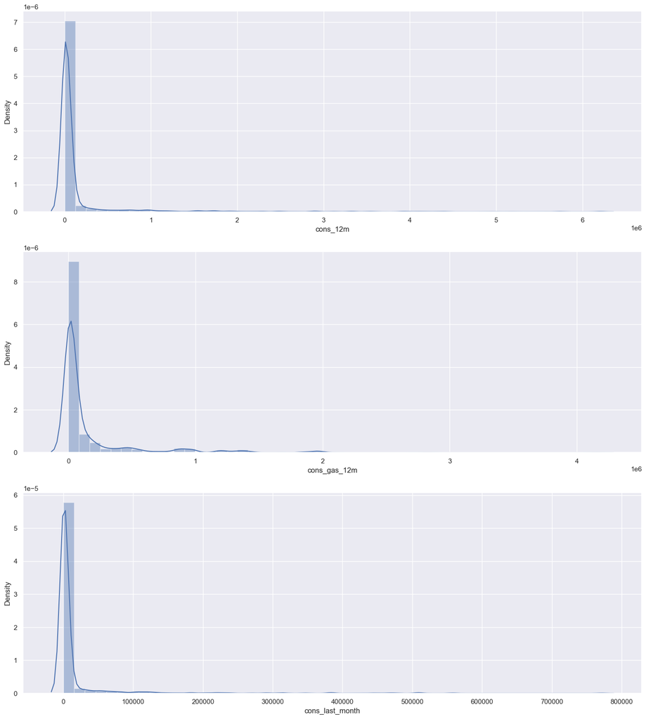

```python
ig, axs = plt.subplots(nrows=3, figsize=(18, 20))
# Plot histograms
sns.distplot((df["cons_12m"].dropna()), ax=axs[0])
sns.distplot((df[df["has_gas"]==1]["cons_gas_12m"].dropna()), ax=axs[1])
sns.distplot((df["cons_last_month"].dropna()), ax=axs[2])
plt.show()
```

As we saw during exploratory data analysis, the distribution of some columns was skewed. This is important to identify because when modeling data for prediction, based on the technique or algorithm that we use, there are sometimes assumptions within the data that we should follow: One common assumtionp is that the columns within the data are normally distributed. Hence, if we find that columns are not normally distributed, we should treat these columns to try and transform them into a distribution that is more normal.

Therefore, the next thing we do is transform some columns to have a closer to normal distribution. We do this using the logarithm function. As you can see from the visualizations, the newly transformed columns are much closer to a normal distribution than what they were earlier.

```python
# Apply log10 transformation
df["cons_12m"] = np.log10(df["cons_12m"] + 1)
df["cons_gas_12m"] = np.log10(df["cons_gas_12m"] + 1)
df["cons_last_month"] = np.log10(df["cons_last_month"] + 1)
df["forecast_cons_12m"] = np.log10(df["forecast_cons_12m"] + 1)
df["forecast_cons_year"] = np.log10(df["forecast_cons_year"] + 1)
df["forecast_meter_rent_12m"] = np.log10(df["forecast_meter_rent_12m"] + 1)
df["imp_cons"] = np.log10(df["imp_cons"] + 1)
```

```python
df[skewed].describe()
```

|  | cons_12m | cons_gas_12m | cons_last_month | forecast_cons_12m | forecast_cons_year | forecast_discount_energy | forecast_meter_rent_12m | forecast_price_energy_off_peak | forecast_price_energy_peak | forecast_price_pow_off_peak |
| --- | --- | --- | --- | --- | --- | --- | --- | --- | --- | --- |
| count | 175149.000000 | 175149.000000 | 175149.000000 | 175149.000000 | 175149.000000 | 175149.000000 | 175149.000000 | 175149.000000 | 175149.000000 | 175149.000000 |
| mean | 4.223974 | 0.779107 | 2.264762 | 2.962138 | 1.784528 | 0.967028 | 1.517148 | 0.137287 | 0.050487 | 43.130229 |
| std | 0.884530 | 1.716895 | 1.769263 | 0.683576 | 1.584941 | 5.109025 | 0.571421 | 0.024625 | 0.049036 | 4.486779 |
| min | 0.000000 | 0.000000 | 0.000000 | 0.000000 | 0.000000 | 0.000000 | 0.000000 | 0.000000 | 0.000000 | 0.000000 |
| 25% | 3.753966 | 0.000000 | 0.000000 | 2.695464 | 0.000000 | 0.000000 | 1.235023 | 0.116340 | 0.000000 | 40.606701 |
| 50% | 4.149712 | 0.000000 | 2.899273 | 3.046733 | 2.498311 | 0.000000 | 1.296446 | 0.143166 | 0.084138 | 44.311378 |
| 75% | 4.610277 | 0.000000 | 3.529430 | 3.380455 | 3.242044 | 0.000000 | 2.120673 | 0.146348 | 0.098837 | 44.311378 |
| max | 6.792889 | 6.618528 | 5.887169 | 4.918575 | 5.243970 | 30.000000 | 2.778376 | 0.273963 | 0.195975 | 59.266378 |

[output not shown]

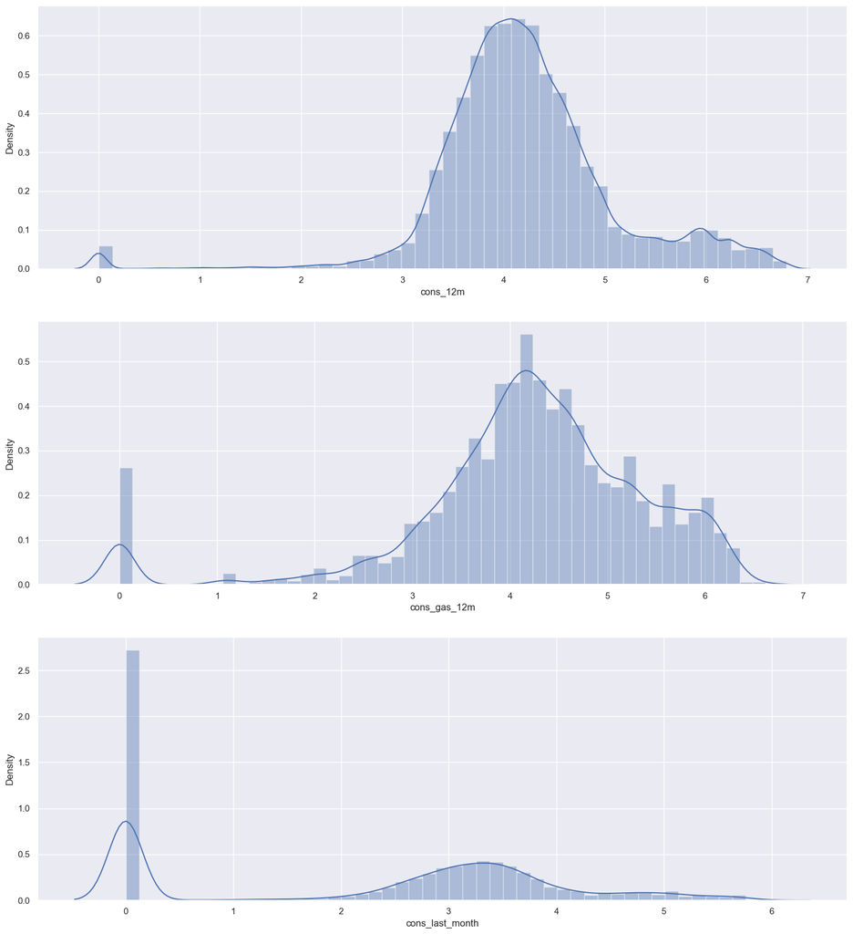

```python
ig, axs = plt.subplots(nrows=3, figsize=(18, 20))
# Plot histograms
sns.distplot((df["cons_12m"].dropna()), ax=axs[0])
sns.distplot((df[df["has_gas"]==1]["cons_gas_12m"].dropna()), ax=axs[1])
sns.distplot((df["cons_last_month"].dropna()), ax=axs[2])
plt.show()
```

Finally, we plot correlations of all the columns to see if we can identify any columns to remove. Columns that have very high correlations indicate an area to look out for. In this case, you may want to remove one of the columns, since they are likely both holding very similar information.

## 3.8 Correlations

In terms of creating new features and transforming existing ones, it is very much a trial and error situation that requires iteration. Once we train a predictive model we can see which features work and don't work, we will also know how predictive this set of features is. Based on this, we can come back to feature engineering to enhance our model.

For now, we will leave feature engineering at this point. Another thing that is always useful to look at is how correlated all of the features are within your dataset.

This is important because it reveals the linear relationships between features. We want features to correlate with churn, as this will indicate that they are good predictors of it.However features that have a very high correlation can sometimes be suspicious. This is because 2 columns that have high correlation indicates that they may share a lot of the same information. One of the assumptions of any parametric predictive model (as stated earlier) is that all features must be independent.

For features to be independent, this means that each feature must have absolutely no dependence on any other feature. If two features are highly correlated and share similar information, this breaks this assumption.

Ideally, you want a set of features that have 0 correlation with all of the independent variables (all feature except our target variable) and a high correlation with the target variable (churn). However, this is very rarely the case and it is common to have a small degree of correlation between independent features.

So now let's look at how all the features within the model are correlated.

```python
df = df.drop(columns = ['id'])
```

```python
correlation = df.corr()
```

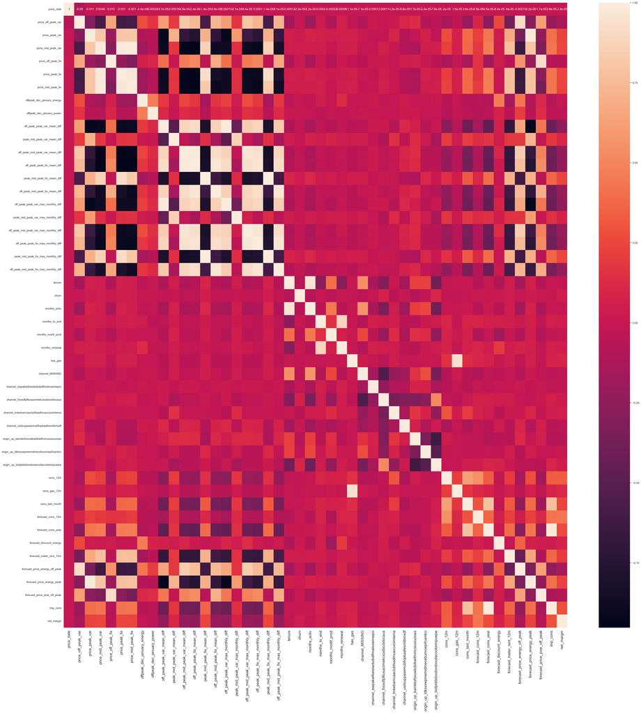

```python
# Plot correlation
plt.figure(figsize = (45,45))
sns.heatmap(correlation, xticklabels = correlation.columns.values, yticklabels = correlation.columns.values, annot = True, annot_kws = {'size': 12})
# Axis ticks size
plt.xticks(fontsize = 15)
plt.xticks(fontsize = 15)
plt.show()
```

```python
# Print correlation
correlation_series = correlation.unstack()
duplicates = set()
for i in range(0, len(correlation.columns)):
    for j in range(i + 1, len(correlation.columns)):
        duplicates.add((correlation.columns[i], correlation.columns[j]))

sorted_correlation = correlation_series.drop(index = duplicates)
sorted_correlation = sorted_correlation[sorted_correlation != 1]

print(sorted_correlation.sort_values(ascending = False).head(30))
```

```
peak_mid_peak_fix_max_monthly_diff      peak_mid_peak_fix_mean_diff               0.996596
off_peak_peak_var_max_monthly_diff      off_peak_peak_var_mean_diff               0.991357
price_mid_peak_fix                      price_mid_peak_var                        0.990798
price_peak_fix                          price_mid_peak_var                        0.986979
forecast_price_energy_peak              price_peak_var                            0.985999
imp_cons                                forecast_cons_year                        0.984259
off_peak_peak_fix_mean_diff             off_peak_mid_peak_var_mean_diff           0.979127
price_mid_peak_fix                      price_peak_fix                            0.974224
off_peak_peak_fix_max_monthly_diff      off_peak_mid_peak_var_max_monthly_diff    0.968894
off_peak_mid_peak_fix_max_monthly_diff  off_peak_peak_fix_max_monthly_diff        0.965956
off_peak_mid_peak_var_max_monthly_diff  off_peak_mid_peak_var_mean_diff           0.964664
off_peak_mid_peak_fix_max_monthly_diff  off_peak_mid_peak_fix_mean_diff           0.963815
off_peak_mid_peak_fix_mean_diff         off_peak_peak_fix_mean_diff               0.963678
off_peak_peak_fix_max_monthly_diff      off_peak_peak_fix_mean_diff               0.960110
months_activ                            tenure                                    0.956418
cons_gas_12m                            has_gas                                   0.941227
off_peak_peak_fix_max_monthly_diff      off_peak_mid_peak_var_mean_diff           0.940129
off_peak_mid_peak_var_max_monthly_diff  off_peak_peak_fix_mean_diff               0.938191
off_peak_mid_peak_fix_max_monthly_diff  off_peak_peak_fix_mean_diff               0.927440
off_peak_peak_fix_max_monthly_diff      off_peak_mid_peak_fix_mean_diff           0.927413
peak_mid_peak_fix_mean_diff             price_peak_fix                            0.924910
off_peak_mid_peak_fix_mean_diff         off_peak_mid_peak_var_mean_diff           0.923536
peak_mid_peak_fix_max_monthly_diff      price_peak_fix                            0.921454
forecast_price_pow_off_peak             price_off_peak_fix                        0.920681
off_peak_peak_fix_mean_diff             off_peak_peak_var_mean_diff               0.920138
off_peak_mid_peak_fix_max_monthly_diff  off_peak_mid_peak_var_max_monthly_diff    0.917917
forecast_price_energy_off_peak          price_off_peak_var                        0.917617
off_peak_peak_var_max_monthly_diff      off_peak_peak_fix_mean_diff               0.909664
off_peak_peak_fix_max_monthly_diff      off_peak_peak_var_max_monthly_diff        0.895591
off_peak_mid_peak_fix_max_monthly_diff  off_peak_mid_peak_var_mean_diff           0.889489
dtype: float64
```

```python
df = df.drop(columns = ['off_peak_peak_var_max_monthly_diff',
    'peak_mid_peak_var_max_monthly_diff',
    'off_peak_mid_peak_var_max_monthly_diff',
    'off_peak_peak_fix_max_monthly_diff',
    'peak_mid_peak_fix_max_monthly_diff',
    'off_peak_mid_peak_fix_max_monthly_diff'])
df.head()
```

|  | price_date | price_off_peak_var | price_peak_var | price_mid_peak_var | price_off_peak_fix | price_peak_fix | price_mid_peak_fix | offpeak_dec_january_energy | offpeak_dec_january_power | off_peak_peak_var_mean_diff | ... | cons_last_month | forecast_cons_12m | forecast_cons_year | forecast_discount_energy | forecast_meter_rent_12m | forecast_price_energy_off_peak | forecast_price_energy_peak | forecast_price_pow_off_peak | imp_cons | net_margin |
| --- | --- | --- | --- | --- | --- | --- | --- | --- | --- | --- | --- | --- | --- | --- | --- | --- | --- | --- | --- | --- | --- |
| 0 | 2015-01-01 | 0.151367 | 0.0 | 0.0 | 44.266931 | 0.0 | 0.0 | -0.005508 | 0.177779 | 0.14855 | ... | 2.800029 | 2.72632 | 2.800029 | 0.0 | 1.313656 | 0.14398 | 0.0 | 44.311378 | 1.967642 | 52.53 |
| 1 | 2015-02-01 | 0.151367 | 0.0 | 0.0 | 44.266931 | 0.0 | 0.0 | -0.005508 | 0.177779 | 0.14855 | ... | 2.800029 | 2.72632 | 2.800029 | 0.0 | 1.313656 | 0.14398 | 0.0 | 44.311378 | 1.967642 | 52.53 |
| 2 | 2015-03-01 | 0.151367 | 0.0 | 0.0 | 44.266931 | 0.0 | 0.0 | -0.005508 | 0.177779 | 0.14855 | ... | 2.800029 | 2.72632 | 2.800029 | 0.0 | 1.313656 | 0.14398 | 0.0 | 44.311378 | 1.967642 | 52.53 |
| 3 | 2015-04-01 | 0.149626 | 0.0 | 0.0 | 44.266931 | 0.0 | 0.0 | -0.005508 | 0.177779 | 0.14855 | ... | 2.800029 | 2.72632 | 2.800029 | 0.0 | 1.313656 | 0.14398 | 0.0 | 44.311378 | 1.967642 | 52.53 |
| 4 | 2015-05-01 | 0.149626 | 0.0 | 0.0 | 44.266931 | 0.0 | 0.0 | -0.005508 | 0.177779 | 0.14855 | ... | 2.800029 | 2.72632 | 2.800029 | 0.0 | 1.313656 | 0.14398 | 0.0 | 44.311378 | 1.967642 | 52.53 |

5 rows × 42 columns

# 4. Modelling

Can we use this dataset to accurately make predictions? If so, are they reliable?

We now have a dataset containing features that we have engineered and we are ready to start training a predictive model. Remember, we only need to focus on training a Random Forest classifier.

## 4.1 Data sampling

The first thing we want to do is split our dateset into training and test samples. The reason why we do this, is so that we can simulate a real life situation by generating predictions for our test sample, without showing the predictive model these data points. This gives us the ability to see how well our model is able to generalise to new data, which is critical.

A typical % to dedicate to testing is between 20-30. For this example we will use a 75-25 split between train and test respectively.

```python
client.info()
```

```
<class 'pandas.core.frame.DataFrame'>
RangeIndex: 14606 entries, 0 to 14605
Data columns (total 31 columns):
 #   Column                          Non-Null Count  Dtype
---  ------                          --------------  -----
 0   id                              14606 non-null  object
 1   channel_sales                   14606 non-null  object
 2   cons_12m                        14606 non-null  int64
 3   cons_gas_12m                    14606 non-null  int64
 4   cons_last_month                 14606 non-null  int64
 5   date_activ                      14606 non-null  datetime64[ns]
 6   date_end                        14606 non-null  datetime64[ns]
 7   date_modif_prod                 14606 non-null  datetime64[ns]
 8   date_renewal                    14606 non-null  datetime64[ns]
 9   forecast_cons_12m               14606 non-null  float64
```

[output cut: 23 more lines]

```python
df = df.drop(columns = ['price_date'])
```

```python
# Make a copy of our data
train_df = df.copy

# Separate target variable from independent variables
y = df['churn']
X = df.drop(columns = ['churn'])
print(X.shape)
print(y.shape)
```

```
(175149, 40)
(175149,)
```

```python
X_train, X_test, y_train, y_test = train_test_split(X, y, test_size = 0.25, random_state = 42)
print(X_train.shape)
print(X_test.shape)
print(y_train.shape)
print(y_test.shape)
```

```
(131361, 40)
(43788, 40)
(131361,)
(43788,)
```

## 4.2 Model training

Once again, we are using a Random Forest classifier in this example. A Random Forest sits within the category ensemble algorithm because internally the Forest refers to a collection of Decision Trees which are tree-based learning algorithm. We can control how large the forest is (that is, how many decision trees you want to include).

The reason why an ensemble algorithm is powerfull is because of the laws of averaging, week learners and the central limit theorem. If we take a single decision tree and give it a sample of data and some parameters, it will learn patterns from the data. It may be overfit or it may be underfit, but that is now our only hope, that single algorithm.

With ensemble methods, instead of banking on 1 single trained model, we can train 1000's of decision trees, all using different splits of the data and learning different patterns. It would be like asking 1000 people to all learn how to code. You would end up with 1000 people with different answers, methods and styles. The weak learner notion applies here too, it has been found that if you train your learners not to overfit, but to learn weal patterns within the data and you have a lot of these weak learners, together they come together to form a highly predictive pool of knowledge. This is a real life application of many brains are better than 1.

Now instead of relying on 1 single decision tree for prediction, the random forest puts it to the overall views of the entire collection of decision trees. Some ensemble algorithm using a voting approach to decide which prediction is best, others using averageing.

As we increase the number of learners, the idea is that the random forest's performance should converge to its best possible solution.

Some additional advantages of the random forest classifier include:

- The random forest uses a rule-baseed approach instead of a distance calculation and so features do not need to be scaled.
- It is able to handle non-linear parameters better than linear based models.

On the filp side, some disadvantages of the random forest classifier include:

- The computational power need to train a random forest on a large dataset is high, since we need to build a whole ensemble of estimators.
- Training time can be longer due to the increased complexity and size of the ensemble.

```python
model = RandomForestClassifier(max_depth = 10, n_estimators = 100)
model.fit(X_train, y_train)
```

```
RandomForestClassifier(max_depth=10)
```

A random forest is a supervised learning algorithm which means that you must provide the algorithm with a set of features, as well as the outcome that you are trying to predict, in our case churn.

The way it makes predictions is by building a set of decision trees on different samples of the data and by taking a majority vote to decide what prediction to make.

## 4.3. Evaluation

Now, let's evaluate how well this trained model is able to predict the values of the test dataset.

We are going to use 3 metrics to evaluate performance.

- Accuracy = the ratio of correctly predicted observations to the total observations.
- Precision = the ability of the classifier to not label a negative sample as positve.
- Recall = the ability of the classifier to find all the positive samples.

The reason why we are using these three metrics is because a simple accuracy is not always a good measure to use. To give an example, let's say you are predicting heart failures with patients in a hospital and there were 100 patients out of 1000 that did have a heart failure.

If you predicted 80 out of 100 (80%) of the patients that did have a heart failure correctly, you might think that you have done well. However, this also means that you predicted 20 wrong and what may the implications of predicting these remaining 20 patients wrong? Maybe they miss out on getting vital treatment to save their lives.

As well as this, what about the impact of predicting negative cases as positive (people not having heart failure being predicted than they did), maybe a high number of false positives means that resources get used up on thes wrong people and a lot of time is wasted when they could have been helping the real heart failure sufferes.

This is just an example, but it illustrates why other performance metrics are necessary such Precision and Recall, which are good measures to use in a classification scenario.

```python
predictions = model.predict(X_test)
```

```python
y_test.value_counts()
```

```
churn
0    39562
1     4226
Name: count, dtype: int64
```

```python
cm = confusion_matrix(y_test, predictions)
print(cm)
```

```
[[39562     0]
 [ 3914   312]]
```

```python
report = classification_report(y_test, predictions)
print(report)
```

```
              precision    recall  f1-score   support

           0       0.91      1.00      0.95     39562
           1       1.00      0.07      0.14      4226

    accuracy                           0.91     43788
   macro avg       0.95      0.54      0.55     43788
weighted avg       0.92      0.91      0.87     43788
```

# 5. Insights and Recommendations

How we can communicate the value of these predictions explaining them in a way that matters to the business?

A simple way of understanding the results of a model is to look at feature importances. Feature importances indicate the importance of a feature within the predictive model, there are several ways to calculate feature importance, but with the Random Forest classifier, we are able to extract feature importances using the built-in method on the trained model. In the Random Forest case, the feature importance represents the number of times each feature is used for splitting across all trees.

```python
feature_importances = pd.DataFrame({'features': X_train.columns, 'importance': model.feature_importances_}).sort_values(by = 'importance', ascending = True).reset_index()
```

```python
feature_importances.head()
```

|  | index | features | importance |
| --- | --- | --- | --- |
| 0 | 4 | price_peak_fix | 0.001434 |
| 1 | 5 | price_mid_peak_fix | 0.001691 |
| 2 | 3 | price_off_peak_fix | 0.002389 |
| 3 | 33 | forecast_discount_energy | 0.002654 |
| 4 | 21 | channel_ewpakwlliwisiwduibdlfmalxowmwpci | 0.003325 |

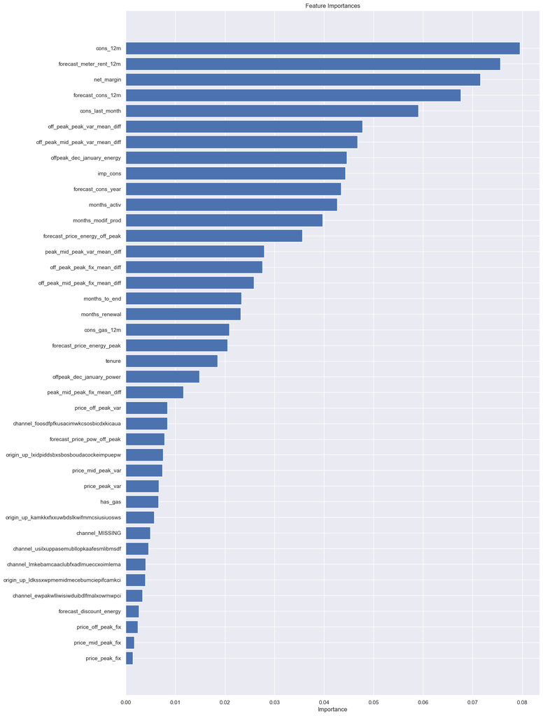

```python
plt.figure(figsize = (15,25))
plt.title('Feature Importances')
plt.barh(range(len(feature_importances)), feature_importances['importance'], color = 'b')
plt.yticks(range(len(feature_importances)), feature_importances['features'])
plt.xlabel('Importance')
plt.show()
```

**Is churn driven by the customers'price sensitivity ?**

Based on the output of the feature importances, it is not a main driver but it is a weak contributor.